# DATA 607 Final Project

John Grando

November 8, 2017

# DATA 607 Final Project

## Purpose

Advanced Statistics are making a major impact in the National Hockey League. This is a professional sport where the amount of money a team can spend on average (Salary Cap Hit) is strictly limited. Therefore, decisions on how much, and how long, to pay players are crucial to a team’s success. Typically, these contract negotians include some type of ‘comparables’ where the performance of other similar players is used to set a market value. The goal for this assignment is as follows:

1. Determine the metrics which best represent player performance as it relates to salary cap.
2. Create a prediction function to estimate a player’s value based on the aforementioned metrics.
3. Use the estimated player values to attempt a prediction on team success.

## Setup

### Required Data Packages

```r
suppressWarnings(suppressMessages(library(XML)))
suppressWarnings(suppressMessages(library(httr)))
suppressWarnings(suppressMessages(library(rvest)))
suppressWarnings(suppressMessages(library(stringr)))
suppressWarnings(suppressMessages(library(dplyr)))
suppressWarnings(suppressMessages(library(tidyr)))
suppressWarnings(suppressMessages(library(data.table)))
suppressWarnings(suppressMessages(library(ggplot2)))
suppressWarnings(suppressMessages(library(ggthemes)))
suppressWarnings(suppressMessages(library(knitr)))
suppressWarnings(suppressMessages(library(kableExtra)))
```

### Necesary Functions

This function is needed to load all the tables of multi-page html files.

```r
fill_df <- function(pages, data_df, url) {
  for(i in 2:pages){
    tmp_url <- paste0(url,i)
    players_html <- read_html(tmp_url)
    tmp_df <- as.data.frame(players_html %>% html_nodes(xpath = "//*/table[@id='brwt']") %>% html_table())
    data_df <- rbind(data_df, tmp_df)
  }
  return(data_df)
}
```

This function formats values to millions.

```r
formattermillion <- function(x){
    x/1000000
}
```

This function formats team names

```r
team_abbr_fun <- function(x) {
  x <- ifelse(grepl("anaheim", tolower(x)), "ANA",
       ifelse(grepl("arizona", tolower(x)), "ARI",
       ifelse(grepl("boston", tolower(x)), "BOS",
       ifelse(grepl("buffalo", tolower(x)), "BUF",
       ifelse(grepl("calgary", tolower(x)), "CGY",
       ifelse(grepl("carolina", tolower(x)), "CAR",
       ifelse(grepl("chicago", tolower(x)), "CHI",
       ifelse(grepl("colorado", tolower(x)), "COL",
       ifelse(grepl("columbus", tolower(x)), "CBJ",
       ifelse(grepl("dallas", tolower(x)), "DAL",
       ifelse(grepl("detroit", tolower(x)), "DET",
       ifelse(grepl("edmonton", tolower(x)), "EDM",
       ifelse(grepl("florida", tolower(x)), "FLA",
       ifelse(grepl("los angeles", tolower(x)), "L.A",
       ifelse(grepl("minnesota", tolower(x)), "MIN",
       ifelse(grepl("montreal", tolower(x)), "MTL",
       ifelse(grepl("nashville", tolower(x)), "NSH",
       ifelse(grepl("new jersey", tolower(x)), "N.J",
       ifelse(grepl("islanders", tolower(x)), "NYI",
       ifelse(grepl("rangers", tolower(x)), "NYR",
       ifelse(grepl("ottawa", tolower(x)), "OTT",
       ifelse(grepl("philadelphia", tolower(x)), "PHI",
       ifelse(grepl("pittsburgh", tolower(x)), "PIT",
       ifelse(grepl("san jose", tolower(x)), "S.J",
       ifelse(grepl("louis", tolower(x)), "STL",
       ifelse(grepl("tampa bay", tolower(x)), "T.B",
       ifelse(grepl("toronto", tolower(x)), "TOR",
       ifelse(grepl("los angeles", tolower(x)), "L.A",
       ifelse(grepl("vancouver", tolower(x)), "VAN",
       ifelse(grepl("vegas", tolower(x)), "VGK",
       ifelse(grepl("washington", tolower(x)), "WSH",
       ifelse(grepl("winnipeg", tolower(x)), "WPG",
       "other"))))))))))))))))))))))))))))))))
}
```

This function applies divisions

```r
team_div_fun <- function(x) {
  x <- ifelse(grepl("ana", tolower(x)), "pacific",
       ifelse(grepl("ari", tolower(x)), "pacific",
       ifelse(grepl("bos", tolower(x)), "atlantic",
       ifelse(grepl("buf", tolower(x)), "atlantic",
       ifelse(grepl("cgy", tolower(x)), "pacific",
       ifelse(grepl("car", tolower(x)), "metropolitan",
       ifelse(grepl("chi", tolower(x)), "central",
       ifelse(grepl("col", tolower(x)), "central",
       ifelse(grepl("cbj", tolower(x)), "metropolitan",
       ifelse(grepl("dal", tolower(x)), "central",
       ifelse(grepl("det", tolower(x)), "atlantic",
       ifelse(grepl("edm", tolower(x)), "pacific",
       ifelse(grepl("fla", tolower(x)), "atlantic",
       ifelse(grepl("l.a.", tolower(x)), "atlantic",
       ifelse(grepl("min", tolower(x)), "central",
       ifelse(grepl("mtl", tolower(x)), "atlantic",
       ifelse(grepl("nsh", tolower(x)), "central",
       ifelse(grepl("n.j", tolower(x)), "metropolitan",
       ifelse(grepl("nyi", tolower(x)), "metropolitan",
       ifelse(grepl("nyr", tolower(x)), "metropolitan",
       ifelse(grepl("ott", tolower(x)), "atlantic",
       ifelse(grepl("phi", tolower(x)), "metropolitan",
       ifelse(grepl("pit", tolower(x)), "metropolitan",
       ifelse(grepl("s.j", tolower(x)), "pacific",
       ifelse(grepl("stl", tolower(x)), "central",
       ifelse(grepl("t.b", tolower(x)), "atlantic",
       ifelse(grepl("tor", tolower(x)), "atlantic",
       ifelse(grepl("l.a", tolower(x)), "pacific",
       ifelse(grepl("van", tolower(x)), "pacific",
       ifelse(grepl("vgk", tolower(x)), "pacific",
       ifelse(grepl("wsh", tolower(x)), "metropolitan",
       ifelse(grepl("wpg", tolower(x)), "central",
       "other"))))))))))))))))))))))))))))))))
}
```

### Load html files, convert date to data frames and clean

```r
#Even Strength
nst_on_ice_doc_2015 <- read_html("https://www.naturalstattrick.com/playerteams.php?season=20142015&stype=2&sit=5v5&score=all&stdoi=oi&rate=n&team=ALL&pos=S&loc=B&toi=0&gpfilt=none&fd=&td=&tgp=82&lines=multi")
nst_individual_doc_2015 <- read_html("https://www.naturalstattrick.com/playerteams.php?season=20142015&stype=2&sit=5v5&score=all&stdoi=std&rate=n&team=ALL&pos=S&loc=B&toi=0&gpfilt=none&fd=&td=&tgp=82&lines=multi")
players_html_2015 <- read_html("https://www.capfriendly.com/browse/active/2015/caphit/all/all/all/desc/1")
nst_team_doc_2015 <- read_html("https://www.naturalstattrick.com/teamtable.php?season=20142015&stype=2&sit=5v5&score=all&rate=n&vs=all&loc=B&gpf=82&fd=2014-10-08&td=2015-04-11")

nst_on_ice_doc_2016 <- read_html("https://www.naturalstattrick.com/playerteams.php?season=20152016&stype=2&sit=5v5&score=all&stdoi=oi&rate=n&team=ALL&pos=S&loc=B&toi=0&gpfilt=none&fd=&td=&tgp=82&lines=multi")
nst_individual_doc_2016 <- read_html("https://www.naturalstattrick.com/playerteams.php?season=20152016&stype=2&sit=5v5&score=all&stdoi=std&rate=n&team=ALL&pos=S&loc=B&toi=0&gpfilt=none&fd=&td=&tgp=82&lines=multi")
players_html_2016 <- read_html("https://www.capfriendly.com/browse/active/2016/caphit/all/all/all/desc/1")
nst_team_doc_2016 <- read_html("https://www.naturalstattrick.com/teamtable.php?season=20152016&stype=2&sit=5v5&score=all&rate=n&vs=all&loc=B&gpf=82&fd=2015-10-07&td=2016-04-10")

nst_on_ice_doc_2017 <- read_html("https://www.naturalstattrick.com/playerteams.php?season=20162017&stype=2&sit=5v5&score=all&stdoi=oi&rate=n&team=ALL&pos=S&loc=B&toi=0&gpfilt=none&fd=&td=&tgp=82&lines=multi")
nst_individual_doc_2017 <- read_html("https://www.naturalstattrick.com/playerteams.php?season=20162017&stype=2&sit=5v5&score=all&stdoi=std&rate=n&team=ALL&pos=S&loc=B&toi=0&gpfilt=none&fd=&td=&tgp=82&lines=multi")
players_html_2017 <- read_html("https://www.capfriendly.com/browse/active/2017/caphit/all/all/all/desc/1")
nst_team_doc_2017 <- read_html("https://www.naturalstattrick.com/teamtable.php?season=20162017&stype=2&sit=5v5&score=all&rate=n&vs=all&loc=B&gpf=82&fd=2016-10-12&td=2017-04-09")

nst_on_ice_doc_2018 <- read_html("https://www.naturalstattrick.com/playerteams.php?season=20172018&stype=2&sit=5v5&score=all&stdoi=oi&rate=n&team=ALL&pos=S&loc=B&toi=0&gpfilt=none&fd=&td=&tgp=82&lines=multi")
nst_individual_doc_2018 <- read_html("https://www.naturalstattrick.com/playerteams.php?season=20172018&stype=2&sit=5v5&score=all&stdoi=std&rate=n&team=ALL&pos=S&loc=B&toi=0&gpfilt=none&fd=&td=&tgp=82&lines=multi")
players_html_2018 <- read_html("https://www.capfriendly.com/browse/active/2018/caphit/all/all/all/desc/1")
nst_team_doc_2018 <- read_html("https://www.naturalstattrick.com/teamtable.php?season=20172018&stype=2&sit=5v5&score=all&rate=n&vs=all&loc=B&gpf=82&fd=2016-10-12&td=2017-04-09")

#PowerPlay
nst_on_ice_doc_2015_pp <- read_html("https://www.naturalstattrick.com/playerteams.php?season=20142015&stype=2&sit=pp&score=all&stdoi=oi&rate=n&team=ALL&pos=S&loc=B&toi=0&gpfilt=none&fd=&td=&tgp=82&lines=multi")
nst_individual_doc_2015_pp <- read_html("https://www.naturalstattrick.com/playerteams.php?season=20142015&stype=2&sit=pp&score=all&stdoi=std&rate=n&team=ALL&pos=S&loc=B&toi=0&gpfilt=none&fd=&td=&tgp=82&lines=multi")

nst_on_ice_doc_2016_pp <- read_html("https://www.naturalstattrick.com/playerteams.php?season=20152016&stype=2&sit=pp&score=all&stdoi=oi&rate=n&team=ALL&pos=S&loc=B&toi=0&gpfilt=none&fd=&td=&tgp=82&lines=multi")
nst_individual_doc_2016_pp <- read_html("https://www.naturalstattrick.com/playerteams.php?season=20152016&stype=2&sit=pp&score=all&stdoi=std&rate=n&team=ALL&pos=S&loc=B&toi=0&gpfilt=none&fd=&td=&tgp=82&lines=multi")

nst_on_ice_doc_2017_pp <- read_html("https://www.naturalstattrick.com/playerteams.php?season=20162017&stype=2&sit=pp&score=all&stdoi=oi&rate=n&team=ALL&pos=S&loc=B&toi=0&gpfilt=none&fd=&td=&tgp=82&lines=multi")
nst_individual_doc_2017_pp <- read_html("https://www.naturalstattrick.com/playerteams.php?season=20162017&stype=2&sit=pp&score=all&stdoi=std&rate=n&team=ALL&pos=S&loc=B&toi=0&gpfilt=none&fd=&td=&tgp=82&lines=multi")

nst_on_ice_doc_2018_pp <- read_html("https://www.naturalstattrick.com/playerteams.php?season=20172018&stype=2&sit=pp&score=all&stdoi=oi&rate=n&team=ALL&pos=S&loc=B&toi=0&gpfilt=none&fd=&td=&tgp=82&lines=multi")
nst_individual_doc_2018_pp <- read_html("https://www.naturalstattrick.com/playerteams.php?season=20172018&stype=2&sit=pp&score=all&stdoi=std&rate=n&team=ALL&pos=S&loc=B&toi=0&gpfilt=none&fd=&td=&tgp=82&lines=multi")

#PenaltyKill
nst_on_ice_doc_2015_pk <- read_html("https://www.naturalstattrick.com/playerteams.php?season=20142015&stype=2&sit=pk&score=all&stdoi=oi&rate=n&team=ALL&pos=S&loc=B&toi=0&gpfilt=none&fd=&td=&tgp=82&lines=multi")
nst_individual_doc_2015_pk <- read_html("https://www.naturalstattrick.com/playerteams.php?season=20142015&stype=2&sit=pk&score=all&stdoi=std&rate=n&team=ALL&pos=S&loc=B&toi=0&gpfilt=none&fd=&td=&tgp=82&lines=multi")

nst_on_ice_doc_2016_pk <- read_html("https://www.naturalstattrick.com/playerteams.php?season=20152016&stype=2&sit=pk&score=all&stdoi=oi&rate=n&team=ALL&pos=S&loc=B&toi=0&gpfilt=none&fd=&td=&tgp=82&lines=multi")
nst_individual_doc_2016_pk <- read_html("https://www.naturalstattrick.com/playerteams.php?season=20152016&stype=2&sit=pk&score=all&stdoi=std&rate=n&team=ALL&pos=S&loc=B&toi=0&gpfilt=none&fd=&td=&tgp=82&lines=multi")

nst_on_ice_doc_2017_pk <- read_html("https://www.naturalstattrick.com/playerteams.php?season=20162017&stype=2&sit=pk&score=all&stdoi=oi&rate=n&team=ALL&pos=S&loc=B&toi=0&gpfilt=none&fd=&td=&tgp=82&lines=multi")
nst_individual_doc_2017_pk <- read_html("https://www.naturalstattrick.com/playerteams.php?season=20162017&stype=2&sit=pk&score=all&stdoi=std&rate=n&team=ALL&pos=S&loc=B&toi=0&gpfilt=none&fd=&td=&tgp=82&lines=multi")

nst_on_ice_doc_2018_pk <- read_html("https://www.naturalstattrick.com/playerteams.php?season=20172018&stype=2&sit=pk&score=all&stdoi=oi&rate=n&team=ALL&pos=S&loc=B&toi=0&gpfilt=none&fd=&td=&tgp=82&lines=multi")
nst_individual_doc_2018_pk <- read_html("https://www.naturalstattrick.com/playerteams.php?season=20172018&stype=2&sit=pk&score=all&stdoi=std&rate=n&team=ALL&pos=S&loc=B&toi=0&gpfilt=none&fd=&td=&tgp=82&lines=multi")
```

```r
team_cap_html <- read_html("https://www.capfriendly.com/")
team_cap_df <- as.data.frame(team_cap_html %>% html_nodes(xpath = "//*/table[@id='ich']") %>% html_table())

season_schedule_html <- read_html("https://www.hockey-reference.com/leagues/NHL_2018_games.html")

#Even Strength
nst_on_ice_players_2015 <- as.data.frame(nst_on_ice_doc_2015 %>% html_nodes(xpath = "//*/table[@id='players']") %>% html_table()) %>% mutate(Player = gsub(pattern = "\u00A0", replacement = '_', x = Player, fixed = TRUE)) %>% mutate(year = 2015)
nst_on_ice_players_2016 <- as.data.frame(nst_on_ice_doc_2016 %>% html_nodes(xpath = "//*/table[@id='players']") %>% html_table()) %>% mutate(Player = gsub(pattern = "\u00A0", replacement = '_', x = Player, fixed = TRUE)) %>% mutate(year = 2016)
nst_on_ice_players_2017 <- as.data.frame(nst_on_ice_doc_2017 %>% html_nodes(xpath = "//*/table[@id='players']") %>% html_table()) %>% mutate(Player = gsub(pattern = "\u00A0", replacement = '_', x = Player, fixed = TRUE)) %>% mutate(year = 2017)
nst_on_ice_players_2018 <- as.data.frame(nst_on_ice_doc_2018 %>% html_nodes(xpath = "//*/table[@id='players']") %>% html_table()) %>% mutate(Player = gsub(pattern = "\u00A0", replacement = '_', x = Player, fixed = TRUE)) %>% mutate(year = 2018)

#Power Play
nst_on_ice_players_2015_pp <- as.data.frame(nst_on_ice_doc_2015_pp %>% html_nodes(xpath = "//*/table[@id='players']") %>% html_table()) %>% mutate(Player = gsub(pattern = "\u00A0", replacement = '_', x = Player, fixed = TRUE)) %>% mutate(year = 2015)
colnames(nst_on_ice_players_2015_pp) <- paste(colnames(nst_on_ice_players_2015_pp), "pp", sep = "_")
nst_on_ice_players_2015_pp <- nst_on_ice_players_2015_pp %>% rename(Player = Player_pp, Team = Team_pp, Position = Position_pp, TOI = TOI_pp, GP = GP_pp, Var.1 = Var.1_pp)

nst_on_ice_players_2016_pp <- as.data.frame(nst_on_ice_doc_2016_pp %>% html_nodes(xpath = "//*/table[@id='players']") %>% html_table()) %>% mutate(Player = gsub(pattern = "\u00A0", replacement = '_', x = Player, fixed = TRUE)) %>% mutate(year = 2016)
colnames(nst_on_ice_players_2016_pp) <- paste(colnames(nst_on_ice_players_2016_pp), "pp", sep = "_")
nst_on_ice_players_2016_pp <- nst_on_ice_players_2016_pp %>% rename(Player = Player_pp, Team = Team_pp, Position = Position_pp, TOI = TOI_pp, GP = GP_pp, Var.1 = Var.1_pp)

nst_on_ice_players_2017_pp <- as.data.frame(nst_on_ice_doc_2017_pp %>% html_nodes(xpath = "//*/table[@id='players']") %>% html_table()) %>% mutate(Player = gsub(pattern = "\u00A0", replacement = '_', x = Player, fixed = TRUE)) %>% mutate(year = 2017)
colnames(nst_on_ice_players_2017_pp) <- paste(colnames(nst_on_ice_players_2017_pp), "pp", sep = "_")
nst_on_ice_players_2017_pp <- nst_on_ice_players_2017_pp %>% rename(Player = Player_pp, Team = Team_pp, Position = Position_pp, TOI = TOI_pp, GP = GP_pp, Var.1 = Var.1_pp)

nst_on_ice_players_2018_pp <- as.data.frame(nst_on_ice_doc_2018_pp %>% html_nodes(xpath = "//*/table[@id='players']") %>% html_table()) %>% mutate(Player = gsub(pattern = "\u00A0", replacement = '_', x = Player, fixed = TRUE)) %>% mutate(year = 2018)
colnames(nst_on_ice_players_2018_pp) <- paste(colnames(nst_on_ice_players_2018_pp), "pp", sep = "_")
nst_on_ice_players_2018_pp <- nst_on_ice_players_2018_pp %>% rename(Player = Player_pp, Team = Team_pp, Position = Position_pp, TOI = TOI_pp, GP = GP_pp, Var.1 = Var.1_pp)

#Penalty Kill
nst_on_ice_players_2015_pk <- as.data.frame(nst_on_ice_doc_2015_pk %>% html_nodes(xpath = "//*/table[@id='players']") %>% html_table()) %>% mutate(Player = gsub(pattern = "\u00A0", replacement = '_', x = Player, fixed = TRUE)) %>% mutate(year = 2015)
colnames(nst_on_ice_players_2015_pk) <- paste(colnames(nst_on_ice_players_2015_pk), "pk", sep = "_")
nst_on_ice_players_2015_pk <- nst_on_ice_players_2015_pk %>% rename(Player = Player_pk, Team = Team_pk, Position = Position_pk, TOI = TOI_pk, GP = GP_pk, Var.1 = Var.1_pk)

nst_on_ice_players_2016_pk <- as.data.frame(nst_on_ice_doc_2016_pk %>% html_nodes(xpath = "//*/table[@id='players']") %>% html_table()) %>% mutate(Player = gsub(pattern = "\u00A0", replacement = '_', x = Player, fixed = TRUE)) %>% mutate(year = 2016)
colnames(nst_on_ice_players_2016_pk) <- paste(colnames(nst_on_ice_players_2016_pk), "pk", sep = "_")
nst_on_ice_players_2016_pk <- nst_on_ice_players_2016_pk %>% rename(Player = Player_pk, Team = Team_pk, Position = Position_pk, TOI = TOI_pk, GP = GP_pk, Var.1 = Var.1_pk)

nst_on_ice_players_2017_pk <- as.data.frame(nst_on_ice_doc_2017_pk %>% html_nodes(xpath = "//*/table[@id='players']") %>% html_table()) %>% mutate(Player = gsub(pattern = "\u00A0", replacement = '_', x = Player, fixed = TRUE)) %>% mutate(year = 2017)
colnames(nst_on_ice_players_2017_pk) <- paste(colnames(nst_on_ice_players_2017_pk), "pk", sep = "_")
nst_on_ice_players_2017_pk <- nst_on_ice_players_2017_pk %>% rename(Player = Player_pk, Team = Team_pk, Position = Position_pk, TOI = TOI_pk, GP = GP_pk, Var.1 = Var.1_pk)

nst_on_ice_players_2018_pk <- as.data.frame(nst_on_ice_doc_2018_pk %>% html_nodes(xpath = "//*/table[@id='players']") %>% html_table()) %>% mutate(Player = gsub(pattern = "\u00A0", replacement = '_', x = Player, fixed = TRUE)) %>% mutate(year = 2018)
colnames(nst_on_ice_players_2018_pk) <- paste(colnames(nst_on_ice_players_2018_pk), "pk", sep = "_")
nst_on_ice_players_2018_pk <- nst_on_ice_players_2018_pk %>% rename(Player = Player_pk, Team = Team_pk, Position = Position_pk, TOI = TOI_pk, GP = GP_pk, Var.1 = Var.1_pk)

#Even Strength
nst_individual_players_2015 <- as.data.frame(nst_individual_doc_2015 %>% html_nodes(xpath = "//*/table[@id='indreg']") %>% html_table()) %>% mutate(Player = gsub(pattern = "\u00A0", replacement = '_', x = Player, fixed = TRUE))
nst_individual_players_2016 <- as.data.frame(nst_individual_doc_2016 %>% html_nodes(xpath = "//*/table[@id='indreg']") %>% html_table()) %>% mutate(Player = gsub(pattern = "\u00A0", replacement = '_', x = Player, fixed = TRUE))
nst_individual_players_2017 <- as.data.frame(nst_individual_doc_2017 %>% html_nodes(xpath = "//*/table[@id='indreg']") %>% html_table()) %>% mutate(Player = gsub(pattern = "\u00A0", replacement = '_', x = Player, fixed = TRUE))
nst_individual_players_2018 <- as.data.frame(nst_individual_doc_2018 %>% html_nodes(xpath = "//*/table[@id='indreg']") %>% html_table()) %>% mutate(Player = gsub(pattern = "\u00A0", replacement = '_', x = Player, fixed = TRUE))
```

```r
#Power Play
nst_individual_players_2015_pp <- as.data.frame(nst_individual_doc_2015_pp %>% html_nodes(xpath = "//*/table[@id='indreg']") %>% html_table()) %>% mutate(Player = gsub(pattern = "\u00A0", replacement = '_', x = Player, fixed = TRUE))
colnames(nst_individual_players_2015_pp) <- paste(colnames(nst_individual_players_2015_pp), "pp", sep = "_")
nst_individual_players_2015_pp <- nst_individual_players_2015_pp %>% rename(Player = Player_pp, Team = Team_pp, Position = Position_pp, TOI = TOI_pp, GP = GP_pp, Var.1 = Var.1_pp)

nst_individual_players_2016_pp <- as.data.frame(nst_individual_doc_2016_pp %>% html_nodes(xpath = "//*/table[@id='indreg']") %>% html_table()) %>% mutate(Player = gsub(pattern = "\u00A0", replacement = '_', x = Player, fixed = TRUE))
colnames(nst_individual_players_2016_pp) <- paste(colnames(nst_individual_players_2016_pp), "pp", sep = "_")
nst_individual_players_2016_pp <- nst_individual_players_2016_pp %>% rename(Player = Player_pp, Team = Team_pp, Position = Position_pp, TOI = TOI_pp, GP = GP_pp, Var.1 = Var.1_pp)

nst_individual_players_2017_pp <- as.data.frame(nst_individual_doc_2017_pp %>% html_nodes(xpath = "//*/table[@id='indreg']") %>% html_table()) %>% mutate(Player = gsub(pattern = "\u00A0", replacement = '_', x = Player, fixed = TRUE))
colnames(nst_individual_players_2017_pp) <- paste(colnames(nst_individual_players_2017_pp), "pp", sep = "_")
nst_individual_players_2017_pp <- nst_individual_players_2017_pp %>% rename(Player = Player_pp, Team = Team_pp, Position = Position_pp, TOI = TOI_pp, GP = GP_pp, Var.1 = Var.1_pp)

nst_individual_players_2018_pp <- as.data.frame(nst_individual_doc_2018_pp %>% html_nodes(xpath = "//*/table[@id='indreg']") %>% html_table()) %>% mutate(Player = gsub(pattern = "\u00A0", replacement = '_', x = Player, fixed = TRUE))
colnames(nst_individual_players_2018_pp) <- paste(colnames(nst_individual_players_2018_pp), "pp", sep = "_")
nst_individual_players_2018_pp <- nst_individual_players_2018_pp %>% rename(Player = Player_pp, Team = Team_pp, Position = Position_pp, TOI = TOI_pp, GP = GP_pp, Var.1 = Var.1_pp)

#Penalty Kill
nst_individual_players_2015_pk <- as.data.frame(nst_individual_doc_2015_pk %>% html_nodes(xpath = "//*/table[@id='indreg']") %>% html_table()) %>% mutate(Player = gsub(pattern = "\u00A0", replacement = '_', x = Player, fixed = TRUE))
colnames(nst_individual_players_2015_pk) <- paste(colnames(nst_individual_players_2015_pk), "pk", sep = "_")
nst_individual_players_2015_pk <- nst_individual_players_2015_pk %>% rename(Player = Player_pk, Team = Team_pk, Position = Position_pk, TOI = TOI_pk, GP = GP_pk, Var.1 = Var.1_pk)

nst_individual_players_2016_pk <- as.data.frame(nst_individual_doc_2016_pk %>% html_nodes(xpath = "//*/table[@id='indreg']") %>% html_table()) %>% mutate(Player = gsub(pattern = "\u00A0", replacement = '_', x = Player, fixed = TRUE))
colnames(nst_individual_players_2016_pk) <- paste(colnames(nst_individual_players_2016_pk), "pk", sep = "_")
nst_individual_players_2016_pk <- nst_individual_players_2016_pk %>% rename(Player = Player_pk, Team = Team_pk, Position = Position_pk, TOI = TOI_pk, GP = GP_pk, Var.1 = Var.1_pk)

nst_individual_players_2017_pk <- as.data.frame(nst_individual_doc_2017_pk %>% html_nodes(xpath = "//*/table[@id='indreg']") %>% html_table()) %>% mutate(Player = gsub(pattern = "\u00A0", replacement = '_', x = Player, fixed = TRUE))
colnames(nst_individual_players_2017_pk) <- paste(colnames(nst_individual_players_2017_pk), "pk", sep = "_")
nst_individual_players_2017_pk <- nst_individual_players_2017_pk %>% rename(Player = Player_pk, Team = Team_pk, Position = Position_pk, TOI = TOI_pk, GP = GP_pk, Var.1 = Var.1_pk)

nst_individual_players_2018_pk <- as.data.frame(nst_individual_doc_2018_pk %>% html_nodes(xpath = "//*/table[@id='indreg']") %>% html_table()) %>% mutate(Player = gsub(pattern = "\u00A0", replacement = '_', x = Player, fixed = TRUE))
colnames(nst_individual_players_2018_pk) <- paste(colnames(nst_individual_players_2018_pk), "pk", sep = "_")
nst_individual_players_2018_pk <- nst_individual_players_2018_pk %>% rename(Player = Player_pk, Team = Team_pk, Position = Position_pk, TOI = TOI_pk, GP = GP_pk, Var.1 = Var.1_pk)

last_page_2015 <- as.numeric(str_match_all(players_html_2015 %>% html_nodes(xpath = "//*/div[@class='r']") %>% html_node('span') %>% html_text(), "of\\s+(\\d+)")[[1]][2])
players_cap_raw_df_2015 <- as.data.frame(players_html_2015 %>% html_nodes(xpath = "//*/table[@id='brwt']") %>% html_table())
players_cap_raw_df_2015 <- fill_df(last_page_2015, players_cap_raw_df_2015, "https://www.capfriendly.com/browse/active/2015/caphit/all/all/all/desc/")

last_page_2016 <- as.numeric(str_match_all(players_html_2016 %>% html_nodes(xpath = "//*/div[@class='r']") %>% html_node('span') %>% html_text(), "of\\s+(\\d+)")[[1]][2])
players_cap_raw_df_2016 <- as.data.frame(players_html_2016 %>% html_nodes(xpath = "//*/table[@id='brwt']") %>% html_table())
players_cap_raw_df_2016 <- fill_df(last_page_2016, players_cap_raw_df_2016, "https://www.capfriendly.com/browse/active/2017/caphit/all/all/all/desc/")

last_page_2017 <- as.numeric(str_match_all(players_html_2017 %>% html_nodes(xpath = "//*/div[@class='r']") %>% html_node('span') %>% html_text(), "of\\s+(\\d+)")[[1]][2])
players_cap_raw_df_2017 <- as.data.frame(players_html_2017 %>% html_nodes(xpath = "//*/table[@id='brwt']") %>% html_table())
players_cap_raw_df_2017 <- fill_df(last_page_2017, players_cap_raw_df_2017, "https://www.capfriendly.com/browse/active/2017/caphit/all/all/all/desc/")

last_page_2018 <- as.numeric(str_match_all(players_html_2018 %>% html_nodes(xpath = "//*/div[@class='r']") %>% html_node('span') %>% html_text(), "of\\s+(\\d+)")[[1]][2])
players_cap_raw_df_2018 <- as.data.frame(players_html_2018 %>% html_nodes(xpath = "//*/table[@id='brwt']") %>% html_table())
players_cap_raw_df_2018 <- fill_df(last_page_2018, players_cap_raw_df_2018, "https://www.capfriendly.com/browse/active/2018/caphit/all/all/all/desc/")
```

```r
nst_team_2015_df <- as.data.frame(nst_team_doc_2015 %>% html_nodes(xpath = "//*/table[@id='teams']") %>% html_table())
nst_team_2015_df$year <- 2015
nst_team_2016_df <- as.data.frame(nst_team_doc_2016 %>% html_nodes(xpath = "//*/table[@id='teams']") %>% html_table())
nst_team_2016_df$year <- 2016
nst_team_2017_df <- as.data.frame(nst_team_doc_2017 %>% html_nodes(xpath = "//*/table[@id='teams']") %>% html_table())
nst_team_2017_df$year <- 2017
nst_team_2018_df <- as.data.frame(nst_team_doc_2018 %>% html_nodes(xpath = "//*/table[@id='teams']") %>% html_table())
nst_team_2018_df$year <- 2018

season_schedule_df <- as.data.frame(season_schedule_html %>% html_nodes(xpath = "//*/table[@id='games']") %>% html_table())
```

```r
#Be kind, rewind.... and cache web scrapes.
#load(url("https://github.com/john-grando/data607-finalproject/raw/master/html_files.RData"))
load("./html_files.RData")
```

```r
#remove duplicate columns
drop <- c("","Position","TOI", "GP", "Var.1")
nst_raw_players_2015 <- left_join(nst_on_ice_players_2015[, !names(nst_on_ice_players_2015) %in% c("Var.1")], nst_individual_players_2015[, !names(nst_individual_players_2015) %in% drop], by = c("Player" = "Player","Team" = "Team")) %>% left_join(nst_on_ice_players_2015_pp[, !names(nst_on_ice_players_2015_pp) %in% drop], by = c("Player" = "Player","Team" = "Team")) %>% left_join(nst_individual_players_2015_pp[, !names(nst_individual_players_2015_pp) %in% drop], by = c("Player" = "Player","Team" = "Team")) %>% left_join(nst_on_ice_players_2015_pk[, !names(nst_on_ice_players_2015_pk) %in% drop], by = c("Player" = "Player","Team" = "Team")) %>% left_join(nst_individual_players_2015_pk[, !names(nst_individual_players_2015_pk) %in% drop], by = c("Player" = "Player","Team" = "Team"))

nst_raw_players_2016 <- left_join(nst_on_ice_players_2016[, !names(nst_on_ice_players_2016) %in% c("Var.1")], nst_individual_players_2016[, !names(nst_individual_players_2016) %in% drop], by = c("Player" = "Player","Team" = "Team")) %>% left_join(nst_on_ice_players_2016_pp[, !names(nst_on_ice_players_2016_pp) %in% drop], by = c("Player" = "Player","Team" = "Team")) %>% left_join(nst_individual_players_2016_pp[, !names(nst_individual_players_2016_pp) %in% drop], by = c("Player" = "Player","Team" = "Team")) %>% left_join(nst_on_ice_players_2016_pk[, !names(nst_on_ice_players_2016_pk) %in% drop], by = c("Player" = "Player","Team" = "Team")) %>% left_join(nst_individual_players_2016_pk[, !names(nst_individual_players_2016_pk) %in% drop], by = c("Player" = "Player","Team" = "Team"))

nst_raw_players_2017 <- left_join(nst_on_ice_players_2017[, !names(nst_on_ice_players_2017) %in% c("Var.1")], nst_individual_players_2017[, !names(nst_individual_players_2017) %in% drop], by = c("Player" = "Player","Team" = "Team")) %>% left_join(nst_on_ice_players_2017_pp[, !names(nst_on_ice_players_2017_pp) %in% drop], by = c("Player" = "Player","Team" = "Team")) %>% left_join(nst_individual_players_2017_pp[, !names(nst_individual_players_2017_pp) %in% drop], by = c("Player" = "Player","Team" = "Team")) %>% left_join(nst_on_ice_players_2017_pk[, !names(nst_on_ice_players_2017_pk) %in% drop], by = c("Player" = "Player","Team" = "Team")) %>% left_join(nst_individual_players_2017_pk[, !names(nst_individual_players_2017_pk) %in% drop], by = c("Player" = "Player","Team" = "Team"))

nst_raw_players_2018 <- left_join(nst_on_ice_players_2018[, !names(nst_on_ice_players_2018) %in% c("Var.1")], nst_individual_players_2018[, !names(nst_individual_players_2018) %in% drop], by = c("Player" = "Player","Team" = "Team")) %>% left_join(nst_on_ice_players_2018_pp[, !names(nst_on_ice_players_2018_pp) %in% drop], by = c("Player" = "Player","Team" = "Team")) %>% left_join(nst_individual_players_2018_pp[, !names(nst_individual_players_2018_pp) %in% drop], by = c("Player" = "Player","Team" = "Team")) %>% left_join(nst_on_ice_players_2018_pk[, !names(nst_on_ice_players_2018_pk) %in% drop], by = c("Player" = "Player","Team" = "Team")) %>% left_join(nst_individual_players_2018_pk[, !names(nst_individual_players_2018_pk) %in% drop], by = c("Player" = "Player","Team" = "Team"))

nst_players_2015 <- nst_raw_players_2015 %>% mutate(Player = as.character(Player)) %>% mutate(Player = gsub("[^[:alpha:]]","_",Player))
keep <- c("PLAYER","EXPIRY","CAP.HIT..")
nst_players_2016 <- nst_raw_players_2016 %>% mutate(Player = as.character(Player)) %>% mutate(Player = gsub("[^[:alpha:]]","_",Player))
keep <- c("PLAYER","EXPIRY","CAP.HIT..")
nst_players_2017 <- nst_raw_players_2017 %>% mutate(Player = as.character(Player)) %>% mutate(Player = gsub("[^[:alpha:]]","_",Player))
nst_players_2018 <- nst_raw_players_2018 %>% mutate(Player = as.character(Player)) %>% mutate(Player = gsub("[^[:alpha:]]","_",Player))
keep <- c("PLAYER","EXPIRY","CAP.HIT..")

players_cap_df_2015 <- players_cap_raw_df_2015[names(players_cap_raw_df_2015) %in% keep] %>% mutate(PLAYER = as.character(trimws(sapply(PLAYER, function(x){str_match_all(x, "\\.(.*)")[[1]][2]})))) %>% mutate(PLAYER = gsub("[^[:alpha:]]","_",PLAYER)) %>% mutate(CAP.HIT.. = as.numeric(gsub("[^0-9]","",CAP.HIT..)))
players_cap_df_2016 <- players_cap_raw_df_2016[names(players_cap_raw_df_2016) %in% keep] %>% mutate(PLAYER = as.character(trimws(sapply(PLAYER, function(x){str_match_all(x, "\\.(.*)")[[1]][2]})))) %>% mutate(PLAYER = gsub("[^[:alpha:]]","_",PLAYER)) %>% mutate(CAP.HIT.. = as.numeric(gsub("[^0-9]","",CAP.HIT..)))
players_cap_df_2017 <- players_cap_raw_df_2017[names(players_cap_raw_df_2017) %in% keep] %>% mutate(PLAYER = as.character(trimws(sapply(PLAYER, function(x){str_match_all(x, "\\.(.*)")[[1]][2]})))) %>% mutate(PLAYER = gsub("[^[:alpha:]]","_",PLAYER)) %>% mutate(CAP.HIT.. = as.numeric(gsub("[^0-9]","",CAP.HIT..)))
players_cap_df_2018 <- players_cap_raw_df_2018[names(players_cap_raw_df_2018) %in% keep] %>% mutate(PLAYER = as.character(trimws(sapply(PLAYER, function(x){str_match_all(x, "\\.(.*)")[[1]][2]})))) %>% mutate(PLAYER = gsub("[^[:alpha:]]","_",PLAYER)) %>% mutate(CAP.HIT.. = as.numeric(gsub("[^0-9]","",CAP.HIT..)))

setnames(players_cap_df_2015, old=c("PLAYER"), new=c("Player"))
setnames(players_cap_df_2016, old=c("PLAYER"), new=c("Player"))
setnames(players_cap_df_2017, old=c("PLAYER"), new=c("Player"))
setnames(players_cap_df_2018, old=c("PLAYER"), new=c("Player"))

full_player_df_2015 <- unique(inner_join(nst_players_2015, players_cap_df_2015, by = "Player"))
full_player_df_2016 <- unique(inner_join(nst_players_2016, players_cap_df_2016, by = "Player"))
full_player_df_2017 <- unique(inner_join(nst_players_2017, players_cap_df_2017, by = "Player"))
full_player_df_2018 <- unique(inner_join(nst_players_2018, players_cap_df_2018, by = "Player"))

full_player_df <- rbind(full_player_df_2015, full_player_df_2016, full_player_df_2017, full_player_df_2018)
```

### Convert stats to per-minute-played metrics

```r
player_per_game_df <- full_player_df[,c("CF","CA","FF","FA","SF","SA","GF","GA","SCF","SCA","HDCF","HDCA","HDGF","HDGA","MDCF","MDCA", "MDGF","MDGA","LDCF","LDCA","LDGF","LDGA","Off..Zone.Faceoffs","Neu..Zone.Faceoffs","Def..Zone.Faceoffs","Goals","Total.Assists", "First.Assists","Second.Assists","Total.Points","Shots","iCF","iSCF","iHDCF", "Rebounds.Created", "PIM", "Total.Penalties", "Minor", "Major", "Misconduct", "Penalties.Drawn", "Giveaways", "Takeaways", "Hits", "Hits.Taken", "Shots.Blocked", "CF_pp", "CA_pp", "FF_pp", "FA_pp", "SF_pp", "SA_pp", "GF_pp", "GA_pp", "SCF_pp", "SCA_pp", "HDCF_pp", "HDCA_pp", "HDGF_pp", "HDGA_pp", "MDCF_pp", "MDCA_pp", "MDGF_pp", "MDGA_pp", "LDCF_pp", "LDCA_pp", "LDGF_pp", "LDGA_pp", "Off..Zone.Faceoffs_pp","Neu..Zone.Faceoffs_pp","Def..Zone.Faceoffs_pp","Goals_pp","Total.Assists_pp", "First.Assists_pp", "Second.Assists_pp", "Total.Points_pp", "Shots_pp", "iCF_pp","iSCF_pp", "iHDCF_pp", "Rebounds.Created_pp", "PIM_pp", "Total.Penalties_pp", "Minor_pp", "Major_pp", "Misconduct_pp", "Penalties.Drawn_pp", "Giveaways_pp", "Takeaways_pp", "Hits_pp", "Hits.Taken_pp", "Shots.Blocked_pp", "CF_pk", "CA_pk", "FF_pk", "FA_pk", "SF_pk", "SA_pk", "GF_pk", "GA_pk", "SCF_pk", "SCA_pk", "HDCF_pk", "HDCA_pk", "HDGF_pk", "HDGA_pk", "MDCF_pk", "MDCA_pk", "MDGF_pk", "MDGA_pk", "LDCF_pk","LDCA_pk", "LDGF_pk","LDGA_pk", "Off..Zone.Faceoffs_pk", "Neu..Zone.Faceoffs_pk", "Def..Zone.Faceoffs_pk","Goals_pk","Total.Assists_pk", "First.Assists_pk", "Second.Assists_pk", "Total.Points_pk", "Shots_pk", "iCF_pk","iSCF_pk", "iHDCF_pk", "Rebounds.Created_pk", "PIM_pk", "Total.Penalties_pk", "Minor_pk", "Major_pk", "Misconduct_pk", "Penalties.Drawn_pk", "Giveaways_pk", "Takeaways_pk", "Hits_pk", "Hits.Taken_pk", "Shots.Blocked_pk")] / full_player_df[,5]
player_per_game_df <- cbind(full_player_df[,1:4],player_per_game_df, full_player_df[,c("TOI","EXPIRY", "CAP.HIT..", "year")])
player_per_game_df$Position <- ifelse(player_per_game_df$Position=="D","D","F")
player_per_game_df$Position <- factor(player_per_game_df$Position, levels = c("F", "D"))
```

## Initial Data Summary

### Team Cap Graph

Here, it is noted that not all teams spend to their maximum cap so it is important to analyze the individual metrics for players.

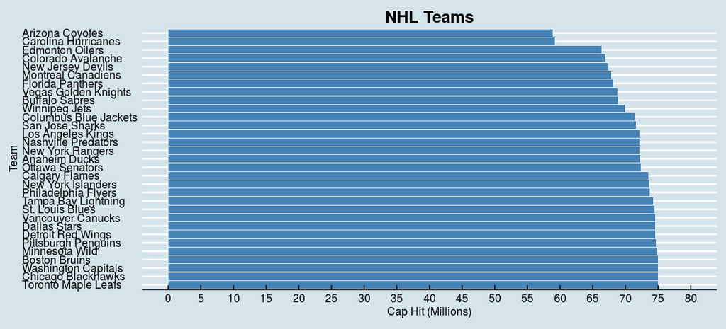

```r
team_cap_df <- team_cap_df %>% mutate(CAP.HIT = 75000000 - as.numeric(gsub('[$,]', '', PROJECTED.CAP.SPACE)))
ggplot(team_cap_df, aes(x=reorder(TEAM, -CAP.HIT), y=CAP.HIT)) + geom_col(fill = "steelblue") + theme_economist() + labs(x = "Team", y = "Cap Hit (Millions)", title = "NHL Teams") + theme(plot.title = element_text(hjust = 0.5), text = element_text(size=12)) + coord_flip() + scale_y_continuous(limits = c(0,80000000), breaks = (seq(0, 80000000, 5000000)), labels = formattermillion)
```

### Player Salary Distributions

This is where the data gets a little challenging. There are actual a few different contract types in the NHL. First, there is an Entry Level Contract (ELC) where a player signs for a relatively fixed amount (typically less than one million per year for three years). Next, there is a Restricted Free Agent Contract (RFA) where a player must sign with their team, and if another team were to extend an “offer sheet” to a player to have him switch teams, it would come with additional compensation to the former team (draft picks). Finally, there are Unrestricted Free Agent Contracts (UFA) where players may sign for any amount or term (with some capped restrictions). In order to try and determine a “true” player value, this analysis tried to focus on UFA contracts by basing a filter on the expiration status of a contract (RFA, UFA) and cap hit (more than one million dollars).

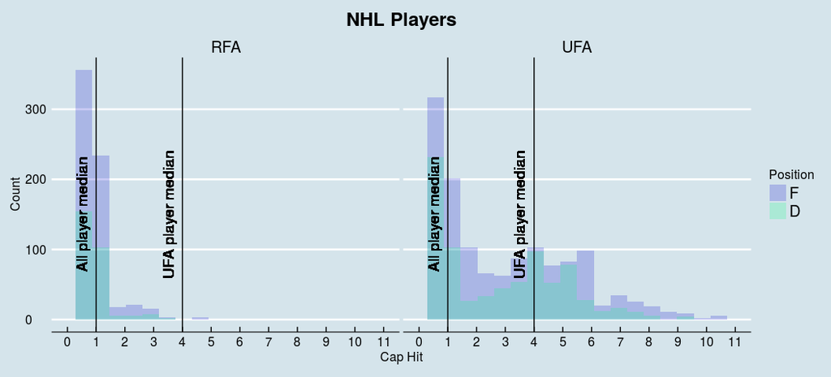

```r
ufa_player_df <- player_per_game_df[player_per_game_df$EXPIRY=="UFA" & player_per_game_df$CAP.HIT..>1000000 & player_per_game_df$GP>41 & player_per_game_df$year < 2018,]
#ufa_player_df <- player_per_game_df[!duplicated(player_per_game_df[,c("Player","CAP.HIT..")]),]
f_per_game_df <- ufa_player_df[ufa_player_df$Position!="D",]
d_per_game_df <- ufa_player_df[ufa_player_df$Position=="D",]
all_median = median(player_per_game_df$CAP.HIT..)
ufa_median = median(ufa_player_df$CAP.HIT..)
#ggplot(player_per_game_df, aes(x=CF, fill=Position)) + geom_histogram(bins = 20)
ggplot(player_per_game_df, aes(x=CAP.HIT.., fill=Position)) + geom_histogram(bins=20, position = "identity", alpha = 0.2) + facet_wrap(~EXPIRY) + geom_vline(xintercept = all_median) + geom_text(aes(x=(all_median-500000), y=150, label="All player median"), angle=90, size = 5) + geom_vline(xintercept = ufa_median) + geom_text(aes(x=(ufa_median-500000), y=150, label="UFA player median"), angle=90, size = 5) + theme_economist() + labs(x = "Cap Hit", y = "Count", title = "NHL Players") + theme(plot.title = element_text(hjust = 0.5), text = element_text(size=12), legend.position = "right") + scale_x_continuous(limits = c(0, 11000000), breaks = (seq(0, 11000000, 1000000)), labels = formattermillion) + scale_fill_manual(values=c("mediumblue", "springgreen"))
```

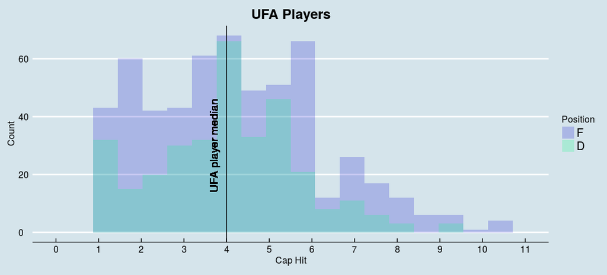

```r
ggplot(ufa_player_df, aes(x=CAP.HIT.., fill=Position)) + geom_histogram(bins=20, position = "identity", alpha = 0.2) + geom_vline(xintercept = ufa_median) + geom_text(aes(x=(ufa_median-300000), y=30, label="UFA player median"), angle=90, size = 5) + theme_economist() + labs(x = "Cap Hit", y = "Count", title = "UFA Players") + theme(plot.title = element_text(hjust = 0.5), text = element_text(size=12), legend.position = "right") + scale_x_continuous(limits = c(0, 11000000), breaks = (seq(0, 11000000, 1000000)), labels = formattermillion) + scale_fill_manual(values=c("mediumblue", "springgreen"))
```

## Analysis

### Mix up the data and separate into training and development sets

Note, since the roles of forwards and defensemen are so different, they have been separately analyzed in this study.

```r
f_complete_player_df <- f_per_game_df[complete.cases(f_per_game_df), ]
d_complete_player_df <- d_per_game_df[complete.cases(d_per_game_df), ]
sample_size <- floor(0.9 * nrow(f_per_game_df))
#set.seed(8345)
f_train_dev_ind <- sample(seq_len(nrow(f_complete_player_df)), size = sample_size)
f_train_df <-f_complete_player_df[f_train_dev_ind,]
f_dev_df <- f_complete_player_df[-f_train_dev_ind,]

sample_size <- floor(0.9 * nrow(d_per_game_df))
#set.seed(3454)
d_train_dev_ind <- sample(seq_len(nrow(d_complete_player_df)), size = sample_size)
d_train_df <-d_complete_player_df[d_train_dev_ind,]
d_dev_df <- d_complete_player_df[-d_train_dev_ind,]
```

### Perform glm regressions with step functions

```r
f_glm <- glm(data = f_train_df, CAP.HIT.. ~ CF + CA + SCF + SCA + HDCF + HDCA + MDCF + MDCA + LDCF + LDCA + Goals + Total.Assists + First.Assists + Second.Assists + Total.Points + Shots + iCF + iSCF + iHDCF + Rebounds.Created + PIM + Total.Penalties + Minor + Major + Misconduct + Penalties.Drawn + Giveaways + Takeaways + Hits + Hits.Taken + Shots.Blocked + CF_pp + CA_pp + SCF_pp + SCA_pp + HDCF_pp + HDCA_pp + MDCF_pp + MDCA_pp + LDCF_pp + LDCA_pp + Goals_pp + Total.Assists_pp + First.Assists_pp + Second.Assists_pp + Total.Points_pp + Shots_pp + iCF_pp + iSCF_pp + iHDCF_pp + Rebounds.Created_pp + PIM_pp + Total.Penalties_pp + Minor_pp + Major_pp + Misconduct_pp + Penalties.Drawn_pp + Giveaways_pp + Takeaways_pp + Hits_pp + Hits.Taken_pp + Shots.Blocked_pp + CF_pk + CA_pk + SCF_pk + SCA_pk + HDCF_pk + HDCA_pk + MDCF_pk + MDCA_pk + LDCF_pk + LDCA_pk + Goals_pk + Total.Assists_pk + First.Assists_pk + Second.Assists_pk + Total.Points_pk + Shots_pk + iCF_pk + iSCF_pk + iHDCF_pk + Rebounds.Created_pk + PIM_pk + Total.Penalties_pk + Minor_pk + Major_pk + Misconduct_pk + Penalties.Drawn_pk + Giveaways_pk + Takeaways_pk + Hits_pk + Hits.Taken_pk + Shots.Blocked_pk, family = "Gamma" (link = 'log'))
step_f_glm <- step(f_glm, trace = FALSE)
summary(step_f_glm)
```

```
##
## Call:
## glm(formula = CAP.HIT.. ~ CF + Goals + Total.Assists + Shots +
##     Total.Penalties + Minor + Hits + Hits.Taken + CA_pp + HDCA_pp +
##     LDCF_pp + LDCA_pp + Total.Assists_pp + Shots_pp + iSCF_pp +
##     Rebounds.Created_pp + PIM_pp + Total.Penalties_pp + HDCF_pk +
##     LDCF_pk + First.Assists_pk + Rebounds.Created_pk + Penalties.Drawn_pk +
##     Hits_pk, family = Gamma(link = "log"), data = f_train_df)
##
## Deviance Residuals:
##      Min        1Q    Median        3Q       Max
## -1.29470  -0.26913  -0.01943   0.20325   0.95269
##
## Coefficients:
##                     Estimate Std. Error t value Pr(>|t|)
## (Intercept)          14.4610     0.1749  82.670  < 2e-16 ***
## CF                    0.3985     0.2106   1.893  0.05902 .
## Goals                -7.9043     4.0790  -1.938  0.05322 .
## Total.Assists         6.5111     3.1911   2.040  0.04186 *
## Shots                 2.2068     0.7110   3.104  0.00202 **
## Total.Penalties     -38.5410    13.6758  -2.818  0.00503 **
## Minor                39.8412    14.0481   2.836  0.00476 **
## Hits                 -0.7118     0.3181  -2.238  0.02569 *
## Hits.Taken           -2.4336     0.5776  -4.213    3e-05 ***
## CA_pp                -5.5106     3.4502  -1.597  0.11087
## HDCA_pp              10.4127     6.1509   1.693  0.09112 .
## LDCF_pp               1.9806     0.6307   3.140  0.00179 **
## LDCA_pp              10.7368     5.7175   1.878  0.06100 .
## Total.Assists_pp     13.4354     4.9954   2.690  0.00740 **
## Shots_pp              7.1821     2.2499   3.192  0.00150 **
## iSCF_pp              -3.1380     2.0841  -1.506  0.13280
## Rebounds.Created_pp -14.1186     8.0648  -1.751  0.08064 .
## PIM_pp               -9.3932     4.2743  -2.198  0.02845 *
## Total.Penalties_pp   27.9850    14.2591   1.963  0.05026 .
## HDCF_pk             -15.5750     5.8429  -2.666  0.00794 **
## LDCF_pk             -11.2844     4.6058  -2.450  0.01464 *
## First.Assists_pk     61.9565    28.0826   2.206  0.02784 *
## Rebounds.Created_pk  93.9461    29.0480   3.234  0.00130 **
## Penalties.Drawn_pk   13.6968     9.0017   1.522  0.12876
## Hits_pk              13.3234     5.7331   2.324  0.02054 *
## ---
## Signif. codes:  0 '***' 0.001 '**' 0.01 '*' 0.05 '.' 0.1 ' ' 1
##
## (Dispersion parameter for Gamma family taken to be 0.118514)
##
##     Null deviance: 134.15  on 509  degrees of freedom
## Residual deviance:  62.58  on 485  degrees of freedom
## AIC: 15847
##
## Number of Fisher Scoring iterations: 5
```

```r
d_glm <- glm(data = d_train_df, CAP.HIT.. ~ CF + CA + SCF + SCA + HDCF + HDCA + MDCF + MDCA + LDCF + LDCA + Goals + Total.Assists + First.Assists + Second.Assists + Total.Points + Shots + iCF + iSCF + iHDCF + Rebounds.Created + PIM + Total.Penalties + Minor + Major + Misconduct + Penalties.Drawn + Giveaways + Takeaways + Hits + Hits.Taken + Shots.Blocked + CF_pp + CA_pp + SCF_pp + SCA_pp + HDCF_pp + HDCA_pp + MDCF_pp + MDCA_pp + LDCF_pp + LDCA_pp + Goals_pp + Total.Assists_pp + First.Assists_pp + Second.Assists_pp + Total.Points_pp + Shots_pp + iCF_pp + iSCF_pp + iHDCF_pp + Rebounds.Created_pp + PIM_pp + Total.Penalties_pp + Minor_pp + Major_pp + Misconduct_pp + Penalties.Drawn_pp + Giveaways_pp + Takeaways_pp + Hits_pp + Hits.Taken_pp + Shots.Blocked_pp + CF_pk + CA_pk + SCF_pk + SCA_pk + HDCF_pk + HDCA_pk + MDCF_pk + MDCA_pk + LDCF_pk + LDCA_pk + Goals_pk + Total.Assists_pk + First.Assists_pk + Second.Assists_pk + Total.Points_pk + Shots_pk + iCF_pk + iSCF_pk + iHDCF_pk + Rebounds.Created_pk + PIM_pk + Total.Penalties_pk + Minor_pk + Major_pk + Misconduct_pk + Penalties.Drawn_pk + Giveaways_pk + Takeaways_pk + Hits_pk + Hits.Taken_pk + Shots.Blocked_pk, family = "Gamma" (link = 'log'))
step_d_glm <- step(d_glm, trace = FALSE)
summary(step_d_glm)
```

```
##
## Call:
## glm(formula = CAP.HIT.. ~ Goals + Shots + iSCF + Giveaways +
##     Hits.Taken + Goals_pp + Shots_pp + iSCF_pp + Rebounds.Created_pp +
##     Total.Penalties_pp + Minor_pp + CA_pk + SCA_pk + LDCA_pk +
##     Total.Assists_pk + PIM_pk + Total.Penalties_pk + Minor_pk +
##     Major_pk + Giveaways_pk + Shots.Blocked_pk, family = Gamma(link = "log"),
##     data = d_train_df)
##
## Deviance Residuals:
##     Min       1Q   Median       3Q      Max
## -1.0242  -0.2119   0.0376   0.1887   0.8680
##
## Coefficients:
##                       Estimate Std. Error t value Pr(>|t|)
## (Intercept)            15.1277     0.1431 105.716  < 2e-16 ***
## Goals                 -46.0468    12.9799  -3.548 0.000458 ***
## Shots                   3.1184     1.7318   1.801 0.072869 .
## iSCF                   -5.2140     2.6791  -1.946 0.052668 .
## Giveaways               4.3435     2.2414   1.938 0.053674 .
## Hits.Taken             -2.9637     0.7568  -3.916 0.000114 ***
## Goals_pp              -38.5531    18.9402  -2.036 0.042772 *
## Shots_pp               13.9465     4.3029   3.241 0.001339 **
## iSCF_pp                 8.9948     4.6933   1.917 0.056351 .
## Rebounds.Created_pp   -46.5350    16.8241  -2.766 0.006066 **
## Total.Penalties_pp    -75.0448    28.0249  -2.678 0.007863 **
## Minor_pp               85.6525    36.2521   2.363 0.018849 *
## CA_pk                 -15.5952     7.5346  -2.070 0.039417 *
## SCA_pk                 18.3569     7.6000   2.415 0.016380 *
## LDCA_pk                16.1416     7.9826   2.022 0.044147 *
## Total.Assists_pk       75.2839    36.4973   2.063 0.040091 *
## PIM_pk                175.5471    94.6712   1.854 0.064785 .
## Total.Penalties_pk  -1722.2645   952.0145  -1.809 0.071548 .
## Minor_pk             1291.7657   760.3607   1.699 0.090488 .
## Major_pk              754.4487   497.5005   1.516 0.130564
## Giveaways_pk           19.4154     8.8868   2.185 0.029764 *
## Shots.Blocked_pk      -10.2652     3.7600  -2.730 0.006747 **
## ---
## Signif. codes:  0 '***' 0.001 '**' 0.01 '*' 0.05 '.' 0.1 ' ' 1
##
## (Dispersion parameter for Gamma family taken to be 0.1190431)
##
##     Null deviance: 64.212  on 292  degrees of freedom
## Residual deviance: 38.490  on 271  degrees of freedom
## AIC: 9141.1
##
## Number of Fisher Scoring iterations: 6
```

### Regression analysis results

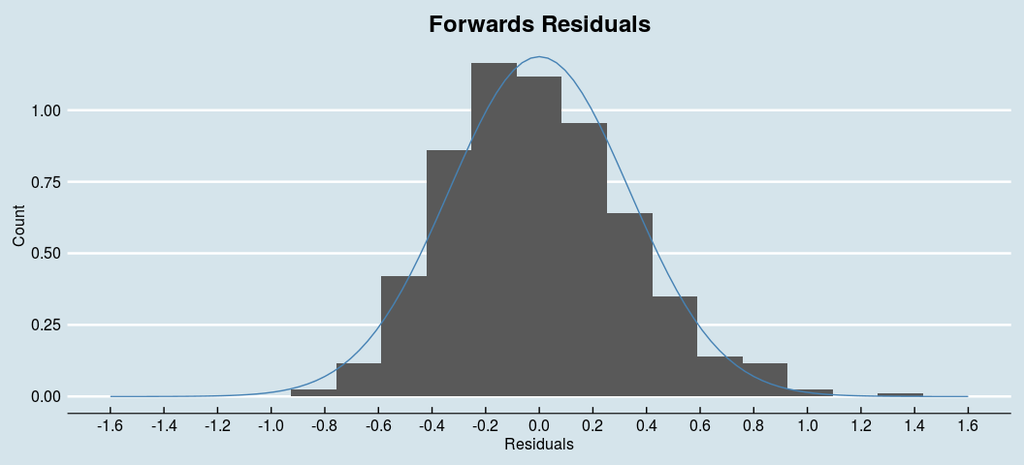

```r
f_train_df$EstCapHit <- step_f_glm$fitted.values
f_train_df$EstCapHit_res <- step_f_glm$residuals
d_train_df$EstCapHit <- step_d_glm$fitted.values
d_train_df$EstCapHit_res <- step_d_glm$residuals

ggplot(f_train_df, aes(x=EstCapHit_res)) + geom_histogram(bins = 20, aes(y = ..density..)) + stat_function(fun=dnorm, color="steelblue", args=list(mean=mean(f_train_df$EstCapHit_res), sd=sd(f_train_df$EstCapHit_res))) + theme_economist() + labs(x = "Residuals", y = "Count", title = "Forwards Residuals") + theme(plot.title = element_text(hjust = 0.5), text = element_text(size=12), legend.position = "right") + scale_x_continuous(limits = c(-1.6, 1.6), breaks = (seq(-1.6, 1.6, 0.2)))
```

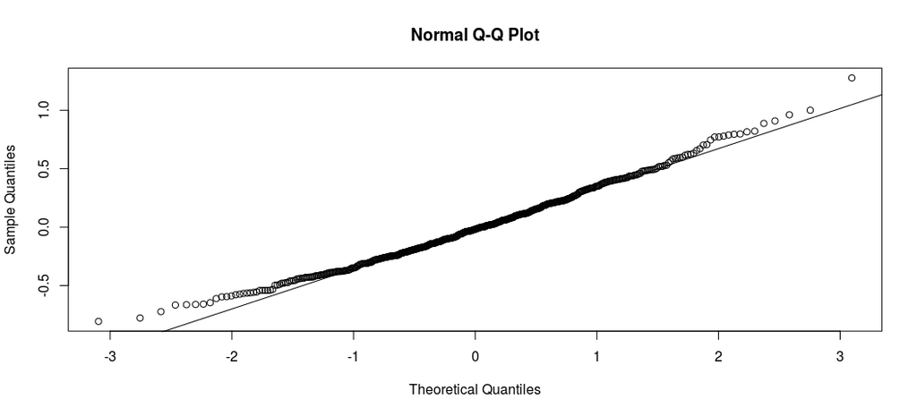

```r
qqnorm(step_f_glm$residuals)
qqline(step_f_glm$residuals)
```

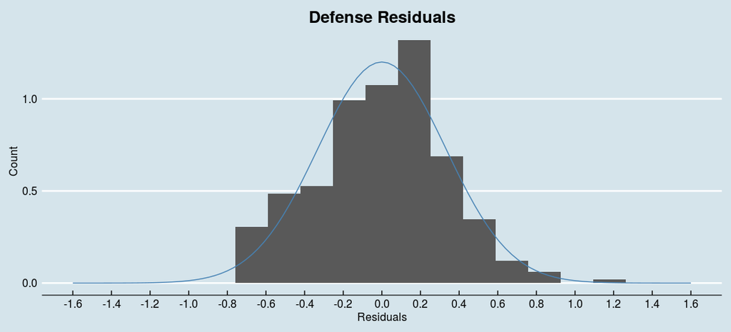

```r
ggplot(d_train_df, aes(x=EstCapHit_res)) + geom_histogram(bins = 20, aes(y = ..density..)) + stat_function(fun=dnorm, color="steelblue", args=list(mean=mean(d_train_df$EstCapHit_res), sd=sd(d_train_df$EstCapHit_res))) + theme_economist() + labs(x = "Residuals", y = "Count", title = "Defense Residuals") + theme(plot.title = element_text(hjust = 0.5), text = element_text(size=12), legend.position = "right") + scale_x_continuous(limits = c(-1.6, 1.6), breaks = (seq(-1.6, 1.6, 0.2)))
```

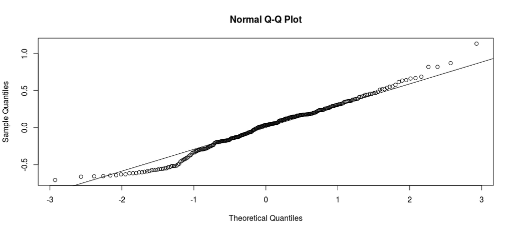

```r
qqnorm(step_d_glm$residuals)
qqline(step_d_glm$residuals)
```

### Test against development data

```r
f_dev_df$EstCapHit <- predict(step_f_glm, f_dev_df, type = "response")

d_dev_df$EstCapHit <- predict(step_d_glm, d_dev_df, type = "response")

f_dev_summary_df <- f_dev_df %>% mutate(variation = 1 - CAP.HIT.. / EstCapHit) %>% summarize(avg = mean(variation), max = max(variation), min = min(variation), sd = sd(variation))
d_dev_summary_df <- d_dev_df %>% mutate(variation = 1 - CAP.HIT.. / EstCapHit) %>% summarize(avg = mean(variation), max = max(variation), min = min(variation), sd = sd(variation))
#variation
f_dev_summary_df
```

```
##           avg       max        min        sd
## 1 -0.08523473 0.7417178 -0.9544127 0.3850882
```

```r
d_dev_summary_df
```

```
##           avg       max      min        sd
## 1 -0.08906767 0.6457476 -1.36668 0.4431727
```

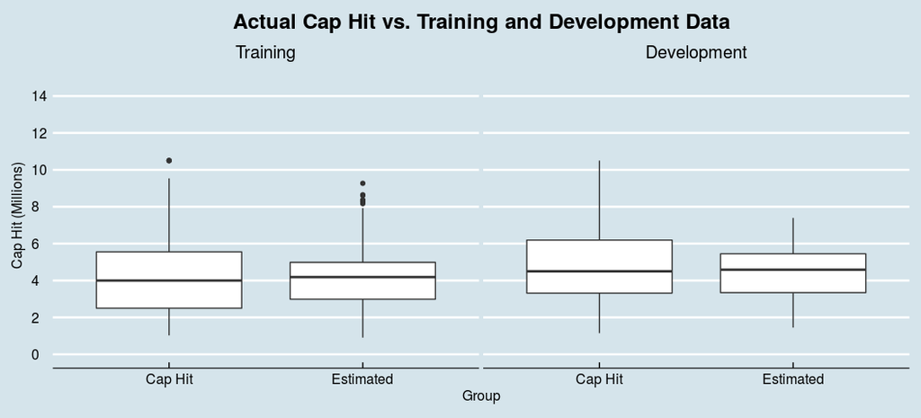

```r
f_train_df$type = "Training"
f_dev_df$type = "Development"
f_train_dev_df <- rbind(f_train_df[,c("type","CAP.HIT..", "EstCapHit")], f_dev_df[,c("type","CAP.HIT..", "EstCapHit")]) %>% gather(captype, "value", 2:3)
f_train_dev_df <- transform(f_train_dev_df, type=factor(type, levels=c("Training","Development")))
ggplot(f_train_dev_df, aes(x = captype, y=value)) + geom_boxplot() + facet_wrap(~type) + theme_economist() + labs(x = "Group", y = "Cap Hit (Millions)", title = "Actual Cap Hit vs. Training and Development Data") + theme(plot.title = element_text(hjust = 0.5), text = element_text(size=12), legend.position = "right") + scale_y_continuous(limits = c(0, 15000000), breaks = (seq(0, 15000000, 2000000)), labels = formattermillion) + scale_x_discrete(labels = c("Cap Hit", "Estimated"))
```

## Application of Results

### Apply glm predictions to all data

```r
player_per_game_df[is.na(player_per_game_df)] <- 0
player_per_game_df$EstCapHit <- ifelse(player_per_game_df$Position!="D", predict(step_f_glm, player_per_game_df, type = "response"), predict(step_d_glm, player_per_game_df, type = "response"))

player_f_det_df <- player_per_game_df %>% filter(Position != "D") %>% select(Player, Team, year, CF, Goals, Total.Assists, Shots, Total.Penalties, Minor, Takeaways, Hits.Taken, CF_pp, CA_pp, SCA_pp, HDCF_pp, LDCA_pp, Goals_pp, Total.Assists_pp, Shots_pp, iSCF_pp, iHDCF_pp, SCA_pk, HDCF_pk, HDCA_pk, Total.Assists_pk, iCF_pk, iSCF_pk, Rebounds.Created_pk, Penalties.Drawn_pk, CAP.HIT.., EstCapHit)

player_d_det_df <- player_per_game_df %>% filter(Position == "D") %>% select(Player, Team, year, Goals, Shots, iSCF, Hits.Taken, Shots.Blocked, CF_pp, SCF_pp, LDCF_pp, Shots_pp, Rebounds.Created_pp, PIM_pp, Total.Penalties_pp, Minor_pp, CA_pk, SCA_pk, LDCA_pk, Total.Assists_pk, PIM_pk, Total.Penalties_pk, Minor_pk, Giveaways_pk, EstCapHit)

player_f_df <- player_per_game_df %>% filter(Position != "D") %>% filter(year < 2018) %>% filter(GP > 60) %>% select(Player, Team, year, GP, CAP.HIT.., EstCapHit) %>% rename(Cap_Hit = CAP.HIT.., Estimated_Cap_Hit = EstCapHit)

player_d_df <- player_per_game_df %>% filter(Position == "D") %>% filter(year < 2018) %>% filter(GP > 60) %>% select(Player, Team, year, GP, CAP.HIT.., EstCapHit) %>% rename(Cap_Hit = CAP.HIT.., Estimated_Cap_Hit = EstCapHit)
```

### Higest value forwards historically

```r
head(player_f_df %>% arrange(-Estimated_Cap_Hit), n = 20) %>% kable("html") %>% kable_styling()
```

| Player | Team | year | GP | Cap_Hit | Estimated_Cap_Hit |
| --- | --- | --- | --- | --- | --- |
| Tyler_Seguin | DAL | 2017 | 82 | 5750000 | 9268629 |
| Alex_Ovechkin | WSH | 2015 | 81 | 9538462 | 8646101 |
| Alex_Ovechkin | WSH | 2016 | 79 | 9538462 | 8607907 |
| Alex_Ovechkin | WSH | 2017 | 82 | 9538462 | 8358887 |
| Jason_Spezza | DAL | 2015 | 82 | 7000000 | 8353137 |
| Tyler_Seguin | DAL | 2015 | 71 | 5750000 | 8346140 |
| Claude_Giroux | PHI | 2016 | 78 | 8275000 | 8269244 |
| Phil_Kessel | TOR | 2015 | 82 | 8000000 | 8260585 |
| Radim_Vrbata | VAN | 2015 | 79 | 5000000 | 8168015 |
| Claude_Giroux | PHI | 2015 | 81 | 8275000 | 7920025 |
| Jason_Spezza | DAL | 2016 | 75 | 7500000 | 7786893 |
| Claude_Giroux | PHI | 2017 | 82 | 8275000 | 7743459 |
| Joe_Thornton | S.J | 2016 | 82 | 6750000 | 7696301 |
| Tyler_Seguin | DAL | 2016 | 72 | 5750000 | 7664990 |
| Phil_Kessel | PIT | 2017 | 82 | 8000000 | 7664306 |
| Mike_Hoffman | OTT | 2017 | 74 | 5187500 | 7601474 |
| Phil_Kessel | PIT | 2016 | 82 | 8000000 | 7531141 |
| Steven_Stamkos | T.B | 2016 | 77 | 7500000 | 7487065 |
| Patrice_Bergeron | BOS | 2017 | 79 | 6875000 | 7392046 |
| Patrick_Kane | CHI | 2015 | 61 | 6300000 | 7384304 |

### Higest value defensemen historically

```r
head(player_d_df %>% arrange(-Estimated_Cap_Hit), n = 20) %>% kable("html") %>% kable_styling()
```

| Player | Team | year | GP | Cap_Hit | Estimated_Cap_Hit |
| --- | --- | --- | --- | --- | --- |
| John_Carlson | WSH | 2017 | 72 | 3966667 | 9442067 |
| P_K__Subban | MTL | 2016 | 68 | 9000000 | 8662409 |
| Keith_Yandle | FLA | 2017 | 82 | 6350000 | 7759714 |
| Shayne_Gostisbehere | PHI | 2017 | 76 | 925000 | 7612498 |
| Kris_Letang | PIT | 2016 | 71 | 7250000 | 7277132 |
| Dougie_Hamilton | BOS | 2015 | 72 | 925000 | 7112278 |
| Drew_Doughty | L.A | 2017 | 82 | 7000000 | 7102464 |
| Dion_Phaneuf | TOR | 2015 | 70 | 7000000 | 7081292 |
| Torey_Krug | BOS | 2016 | 81 | 5250000 | 7002520 |
| Shayne_Gostisbehere | PHI | 2016 | 64 | 925000 | 6992407 |
| Brent_Burns | S.J | 2017 | 82 | 5760000 | 6947552 |
| Sami_Vatanen | ANA | 2017 | 71 | 4875000 | 6917891 |
| Duncan_Keith | CHI | 2017 | 80 | 5538462 | 6898956 |
| Brent_Burns | S.J | 2016 | 82 | 5760000 | 6849753 |
| Mark_Giordano | CGY | 2015 | 61 | 4020000 | 6816895 |
| Shea_Weber | MTL | 2017 | 78 | 7857143 | 6721084 |
| Rasmus_Ristolainen | BUF | 2017 | 79 | 5400000 | 6621681 |
| Ryan_McDonagh | NYR | 2017 | 77 | 4700000 | 6558325 |
| P_K__Subban | MTL | 2015 | 82 | 9000000 | 6474180 |
| Brent_Burns | S.J | 2015 | 82 | 5760000 | 6472722 |

### Higest value forwards this year

```r
player_2018_f_df <- player_per_game_df %>% filter(Position != "D") %>% filter(year == 2018) %>% filter(GP > 5) %>% select(Player, Team, year, CAP.HIT.., EstCapHit) %>% rename(Cap_Hit = CAP.HIT.., Estimated_Cap_Hit = EstCapHit)
head(player_2018_f_df %>% arrange(-Estimated_Cap_Hit), n = 20) %>% kable("html") %>% kable_styling()
```

| Player | Team | year | Cap_Hit | Estimated_Cap_Hit |
| --- | --- | --- | --- | --- |
| Rick_Nash | BOS | 2018 | 7800000 | 15337974 |
| Alex_Ovechkin | WSH | 2018 | 9538462 | 9580111 |
| Blake_Wheeler | WPG | 2018 | 5600000 | 9404201 |
| Steven_Stamkos | T.B | 2018 | 8500000 | 9088800 |
| Nikita_Kucherov | T.B | 2018 | 4766667 | 8731077 |
| Jakub_Voracek | PHI | 2018 | 8250000 | 8727272 |
| Jack_Eichel | BUF | 2018 | 925000 | 8159283 |
| Evgeny_Kuznetsov | WSH | 2018 | 7800000 | 8096383 |
| Evgeni_Malkin | PIT | 2018 | 9500000 | 8028508 |
| Claude_Giroux | PHI | 2018 | 8275000 | 7898732 |
| Patrick_Kane | CHI | 2018 | 10500000 | 7743557 |
| Owen_Tippett | FLA | 2018 | 925000 | 7560376 |
| Ryan_O_Reilly | BUF | 2018 | 7500000 | 7514294 |
| Mike_Hoffman | OTT | 2018 | 5187500 | 7422306 |
| Nathan_MacKinnon | COL | 2018 | 6300000 | 7393286 |
| Patrik_Laine | WPG | 2018 | 925000 | 7393283 |
| Phil_Kessel | PIT | 2018 | 8000000 | 7152004 |
| Joe_Thornton | S.J | 2018 | 8000000 | 7102390 |
| Martin_Frk | DET | 2018 | 650000 | 7016614 |
| Filip_Forsberg | NSH | 2018 | 6000000 | 7013413 |

### Higest value defensemen this year

```r
player_2018_d_df <- player_per_game_df %>% filter(Position == "D") %>% filter(year == 2018) %>% filter(GP > 5) %>% select(Player, Team, year, CAP.HIT.., EstCapHit) %>% rename(Cap_Hit = CAP.HIT.., Estimated_Cap_Hit = EstCapHit)
head(player_2018_d_df %>% arrange(-Estimated_Cap_Hit), n = 20) %>% kable("html") %>% kable_styling()
```

| Player | Team | year | Cap_Hit | Estimated_Cap_Hit |
| --- | --- | --- | --- | --- |
| Keith_Yandle | FLA | 2018 | 6350000 | 10352527 |
| Roman_Josi | NSH | 2018 | 4000000 | 9003682 |
| Sami_Vatanen | ANA | 2018 | 4875000 | 8541978 |
| Ryan_Ellis | NSH | 2018 | 2500000 | 7871080 |
| P_K__Subban | NSH | 2018 | 9000000 | 7522767 |
| Matt_Bartkowski | CGY | 2018 | 612500 | 7483497 |
| Rasmus_Ristolainen | BUF | 2018 | 5400000 | 7472244 |
| Oscar_Klefbom | EDM | 2018 | 4167000 | 7457325 |
| Dustin_Byfuglien | WPG | 2018 | 7600000 | 7403943 |
| Kevin_Shattenkirk | NYR | 2018 | 6650000 | 7050233 |
| Shayne_Gostisbehere | PHI | 2018 | 4500000 | 6698563 |
| Brent_Burns | S.J | 2018 | 8000000 | 6606167 |
| Duncan_Keith | CHI | 2018 | 5538462 | 6356522 |
| TJ_Brodie | CGY | 2018 | 4650400 | 6285750 |
| John_Carlson | WSH | 2018 | 3966667 | 6283926 |
| Jacob_Trouba | WPG | 2018 | 2812500 | 6206838 |
| Erik_Karlsson | OTT | 2018 | 6500000 | 6127814 |
| Cody_Franson | CHI | 2018 | 1000000 | 6070852 |
| Shea_Weber | MTL | 2018 | 7857143 | 5960263 |
| Ron_Hainsey | TOR | 2018 | 3000000 | 5864058 |

### For team analysis, limit the maximum and minimums to realistic values

```r
player_per_game_df$EstCapHit <- sapply(player_per_game_df$EstCapHit, function(x){
  x <- ifelse(x > 15000000, 15000000, x)
})
player_per_game_df$EstCapHit <- sapply(player_per_game_df$EstCapHit, function(x){
  x <- ifelse(x < 650000, 650000, x)
})
```

### Format Team Stats

```r
nst_team_stats_df <- rbind(nst_team_2015_df, nst_team_2016_df, nst_team_2017_df, nst_team_2018_df)
nst_team_stats_df$points <- nst_team_stats_df$W * 2 + nst_team_stats_df$OTL

nst_team_stats_df$teamabbr <- team_abbr_fun(nst_team_stats_df$Team)

player_per_game_df$CapxTOI <- player_per_game_df$CAP.HIT.. * player_per_game_df$TOI
player_per_game_df$EstCapxTOI <- player_per_game_df$EstCapHit * player_per_game_df$TOI
team_player_summary_df <- player_per_game_df %>% filter(GP>10) %>% mutate(countcolumn = 1) %>% group_by(Team, year) %>% summarize(weighted = sum(CapxTOI), estweighted = sum(EstCapxTOI), captotal = sum(CAP.HIT..), time = sum(TOI), players = sum(countcolumn)) %>% mutate(weighted_cap = weighted / time) %>% mutate(est_weighted_cap = estweighted / time) %>% mutate(cap = captotal / sum(players))
keep <- c("teamabbr", "year", "GP","points", "PDO", "SV.", "W", "CF.", "FF.", "SF.", "LDSV.", "MDSV.", "HDSV.", "GF", "GP", "HDCF")
team_summary_df <- merge(team_player_summary_df, nst_team_stats_df[,names(nst_team_stats_df) %in% keep], by.x = c("Team", "year"), by.y = c("teamabbr", "year")) %>% mutate(year = factor(year))
team_past_summary_df <- team_summary_df %>% filter(year!=2018)
```

### Team Results compared to weighted player values

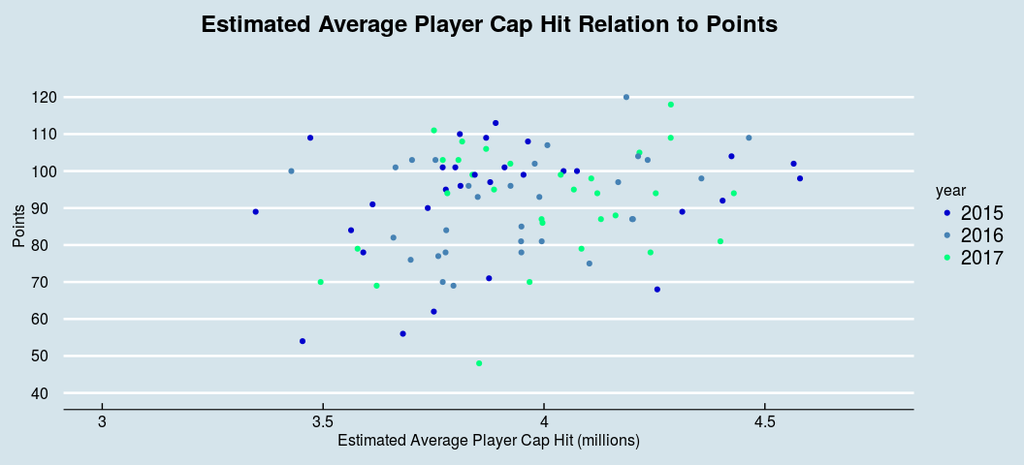

```r
ggplot(team_past_summary_df, aes(x=est_weighted_cap, y=points, color=year)) + geom_point() + theme_economist() + labs(x = "Estimated Average Player Cap Hit (millions)", y = "Points", title = "Estimated Average Player Cap Hit Relation to Points") + theme(plot.title = element_text(hjust = 0.5), text = element_text(size=12), legend.position = "right") + scale_x_continuous(limits = c(3000000, 4750000), breaks = (seq(3000000, 4720000, 500000)), labels = formattermillion) + scale_y_continuous(limits = c(40, 130), breaks = (seq(40, 120, 10))) + scale_color_manual(values = c("mediumblue", "steelblue", "springgreen"))
```

### Run glm based on weighted player values and save percentage

I have added in the varying types of save percentage (shots from low-danger, mid-danger, and high-danger areas) since this study has not included the impact of goaltending.

```r
team_lm <- lm(data = team_past_summary_df, points ~ est_weighted_cap + LDSV. + MDSV. + HDSV.)
team_step_lm <- step(team_lm, trace = FALSE)
summary(team_step_lm)
```

```
##
## Call:
## lm(formula = points ~ est_weighted_cap + LDSV. + MDSV. + HDSV.,
##     data = team_past_summary_df)
##
## Residuals:
##     Min      1Q  Median      3Q     Max
## -33.306  -8.282   1.884   8.034  26.811
##
## Coefficients:
##                    Estimate Std. Error t value Pr(>|t|)
## (Intercept)      -1.912e+03  4.331e+02  -4.415 2.95e-05 ***
## est_weighted_cap  1.315e-05  4.815e-06   2.731  0.00767 **
## LDSV.             1.113e+01  4.401e+00   2.529  0.01329 *
## MDSV.             6.403e+00  2.080e+00   3.079  0.00280 **
## HDSV.             2.729e+00  9.217e-01   2.960  0.00398 **
## ---
## Signif. codes:  0 '***' 0.001 '**' 0.01 '*' 0.05 '.' 0.1 ' ' 1
##
## Residual standard error: 12.06 on 85 degrees of freedom
## Multiple R-squared:  0.342,  Adjusted R-squared:  0.3111
## F-statistic: 11.05 on 4 and 85 DF,  p-value: 2.916e-07
```

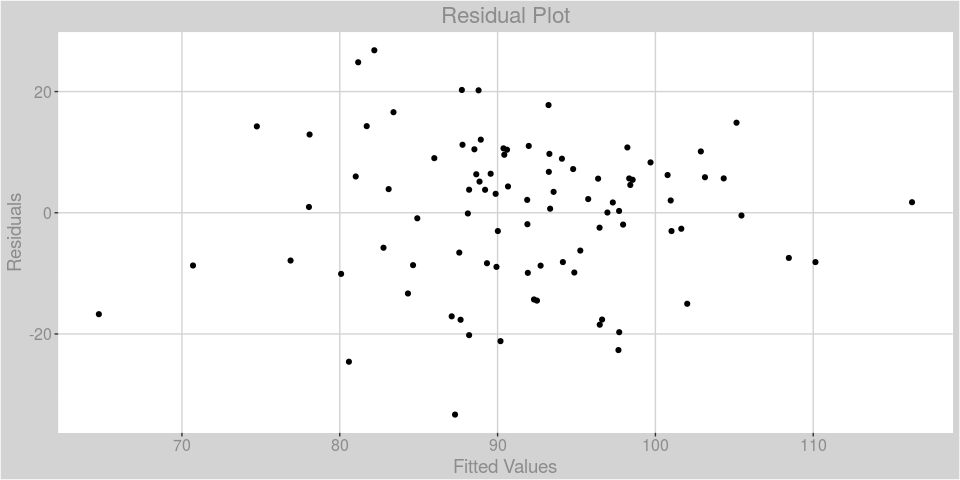

```r
ggplot(data.frame(res = team_lm$residuals, fit = team_lm$fitted.values), aes(x=fit, y = res)) + geom_point() + labs(x="Fitted Values", y="Residuals") + ggtitle("Residual Plot") + theme(plot.title = element_text(hjust = 0.5)) + theme(plot.background = element_rect(fill = "lightgrey"), panel.background = element_rect(fill = "white"), panel.grid.major.x = element_line(color = "lightgrey"), panel.grid.major.y = element_line(color = "lightgrey")) + theme(axis.text = element_text(size=12, color = "grey55"), axis.title = element_text(size=14, color = "grey55"), title = element_text(size=14, color = "grey55"))
```

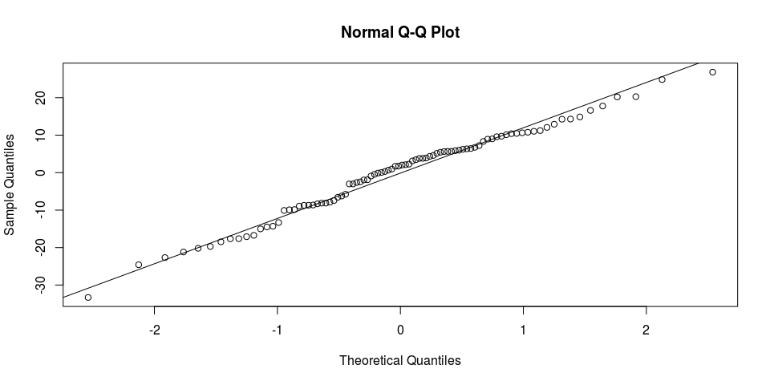

```r
qqnorm(team_lm$residuals)
qqline(team_lm$residuals)
```

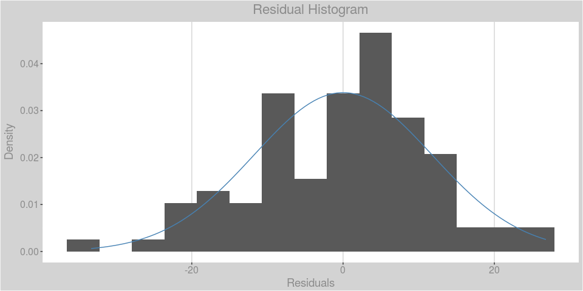

```r
ggplot(data.frame(res = team_lm$residuals), aes(x=res)) + geom_histogram(bins = 15, aes(y = ..density..)) + stat_function(fun=dnorm, color="steelblue", args=list(mean=mean(team_lm$residuals), sd=sd(team_lm$residuals))) + labs(x="Residuals", y="Density") + ggtitle("Residual Histogram") + theme(plot.title = element_text(hjust = 0.5)) + theme(plot.background = element_rect(fill = "lightgrey"), panel.background = element_rect(fill = "white"), panel.grid.major.x = element_line(color = "lightgrey")) + theme(axis.text = element_text(size=12, color = "grey55"), axis.title = element_text(size=14, color = "grey55"), title = element_text(size=14, color = "grey55"))
```

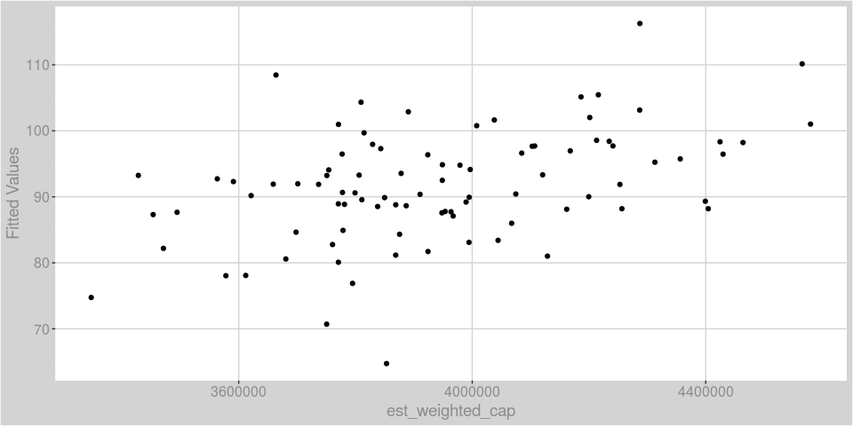

```r
ggplot(data.frame(x = team_past_summary_df$est_weighted_cap, y = team_lm$fitted.values), aes(x=x, y=y)) + geom_point() + labs(x="est_weighted_cap", y="Fitted Values") + theme(plot.title = element_text(hjust = 0.5)) + theme(plot.background = element_rect(fill = "lightgrey"), panel.background = element_rect(fill = "white"), panel.grid.major.x = element_line(color = "lightgrey"), panel.grid.major.y = element_line(color = "lightgrey")) + theme(axis.text = element_text(size=12, color = "grey55"), axis.title = element_text(size=14, color = "grey55"), title = element_text(size=14, color = "grey55"))
```

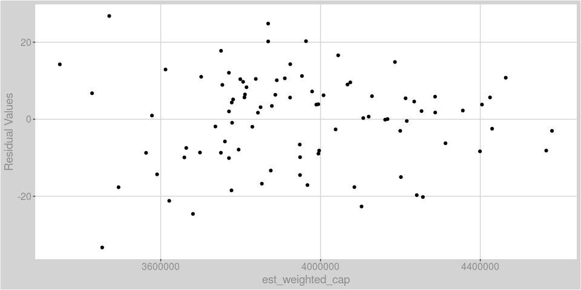

```r
ggplot(data.frame(x = team_past_summary_df$est_weighted_cap, y = team_lm$residuals), aes(x=x, y=y)) + geom_point() + labs(x="est_weighted_cap", y="Residual Values") + theme(plot.title = element_text(hjust = 0.5)) + theme(plot.background = element_rect(fill = "lightgrey"), panel.background = element_rect(fill = "white"), panel.grid.major.x = element_line(color = "lightgrey"), panel.grid.major.y = element_line(color = "lightgrey")) + theme(axis.text = element_text(size=12, color = "grey55"), axis.title = element_text(size=14, color = "grey55"), title = element_text(size=14, color = "grey55"))
```

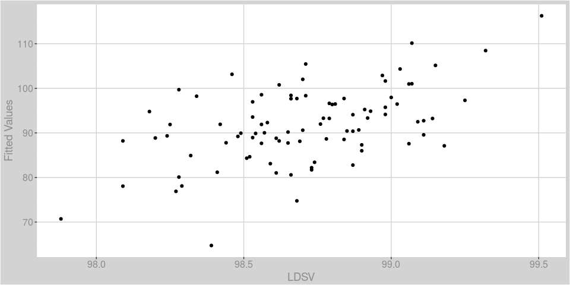

```r
ggplot(data.frame(x = team_past_summary_df$LDSV., y = team_lm$fitted.values), aes(x=x, y=y)) + geom_point() + labs(x="LDSV", y="Fitted Values") + theme(plot.title = element_text(hjust = 0.5)) + theme(plot.background = element_rect(fill = "lightgrey"), panel.background = element_rect(fill = "white"), panel.grid.major.x = element_line(color = "lightgrey"), panel.grid.major.y = element_line(color = "lightgrey")) + theme(axis.text = element_text(size=12, color = "grey55"), axis.title = element_text(size=14, color = "grey55"), title = element_text(size=14, color = "grey55"))
```

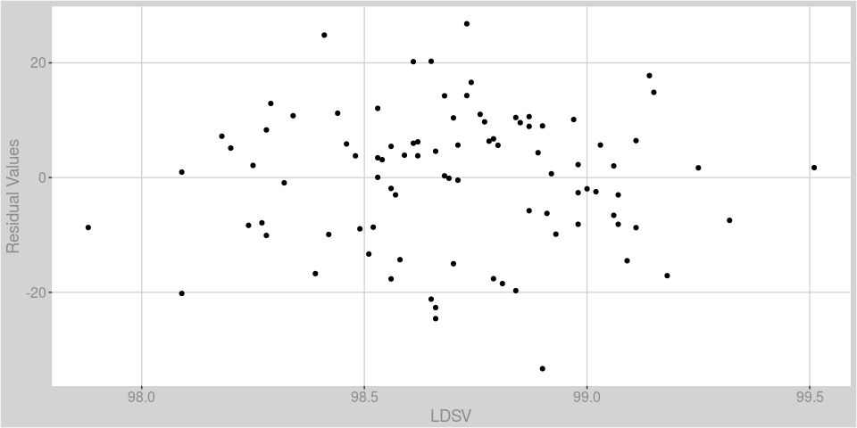

```r
ggplot(data.frame(x = team_past_summary_df$LDSV., y = team_lm$residuals), aes(x=x, y=y)) + geom_point() + labs(x="LDSV", y="Residual Values") + theme(plot.title = element_text(hjust = 0.5)) + theme(plot.background = element_rect(fill = "lightgrey"), panel.background = element_rect(fill = "white"), panel.grid.major.x = element_line(color = "lightgrey"), panel.grid.major.y = element_line(color = "lightgrey")) + theme(axis.text = element_text(size=12, color = "grey55"), axis.title = element_text(size=14, color = "grey55"), title = element_text(size=14, color = "grey55"))
```

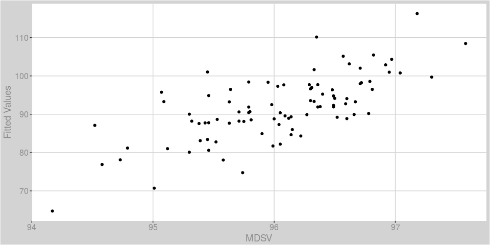

```r
ggplot(data.frame(x = team_past_summary_df$MDSV., y = team_lm$fitted.values), aes(x=x, y=y)) + geom_point() + labs(x="MDSV", y="Fitted Values") + theme(plot.title = element_text(hjust = 0.5)) + theme(plot.background = element_rect(fill = "lightgrey"), panel.background = element_rect(fill = "white"), panel.grid.major.x = element_line(color = "lightgrey"), panel.grid.major.y = element_line(color = "lightgrey")) + theme(axis.text = element_text(size=12, color = "grey55"), axis.title = element_text(size=14, color = "grey55"), title = element_text(size=14, color = "grey55"))
```

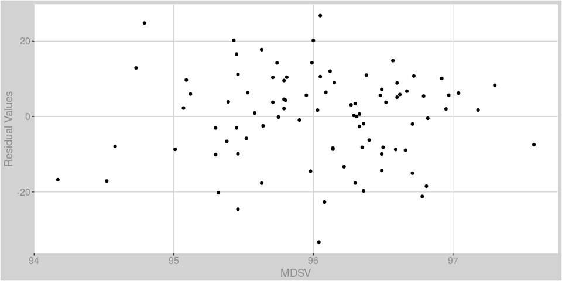

```r
ggplot(data.frame(x = team_past_summary_df$MDSV., y = team_lm$residuals), aes(x=x, y=y)) + geom_point() + labs(x="MDSV", y="Residual Values") + theme(plot.title = element_text(hjust = 0.5)) + theme(plot.background = element_rect(fill = "lightgrey"), panel.background = element_rect(fill = "white"), panel.grid.major.x = element_line(color = "lightgrey"), panel.grid.major.y = element_line(color = "lightgrey")) + theme(axis.text = element_text(size=12, color = "grey55"), axis.title = element_text(size=14, color = "grey55"), title = element_text(size=14, color = "grey55"))
```

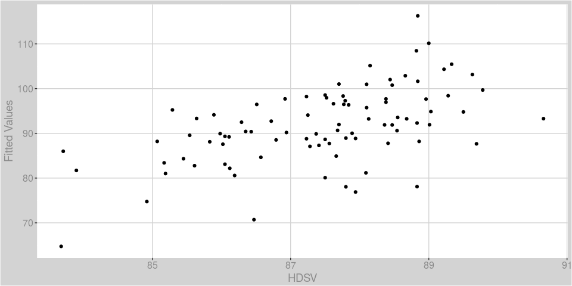

```r
ggplot(data.frame(x = team_past_summary_df$HDSV., y = team_lm$fitted.values), aes(x=x, y=y)) + geom_point() + labs(x="HDSV", y="Fitted Values") + theme(plot.title = element_text(hjust = 0.5)) + theme(plot.background = element_rect(fill = "lightgrey"), panel.background = element_rect(fill = "white"), panel.grid.major.x = element_line(color = "lightgrey"), panel.grid.major.y = element_line(color = "lightgrey")) + theme(axis.text = element_text(size=12, color = "grey55"), axis.title = element_text(size=14, color = "grey55"), title = element_text(size=14, color = "grey55"))
```

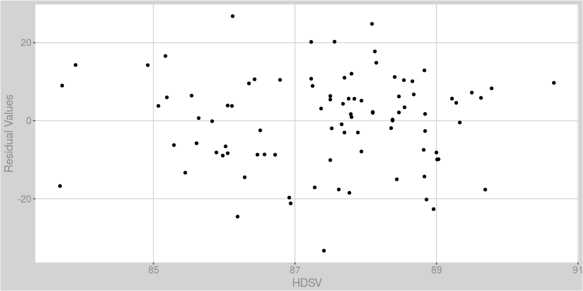

```r
ggplot(data.frame(x = team_past_summary_df$HDSV., y = team_lm$residuals), aes(x=x, y=y)) + geom_point() + labs(x="HDSV", y="Residual Values") + theme(plot.title = element_text(hjust = 0.5)) + theme(plot.background = element_rect(fill = "lightgrey"), panel.background = element_rect(fill = "white"), panel.grid.major.x = element_line(color = "lightgrey"), panel.grid.major.y = element_line(color = "lightgrey")) + theme(axis.text = element_text(size=12, color = "grey55"), axis.title = element_text(size=14, color = "grey55"), title = element_text(size=14, color = "grey55"))
```

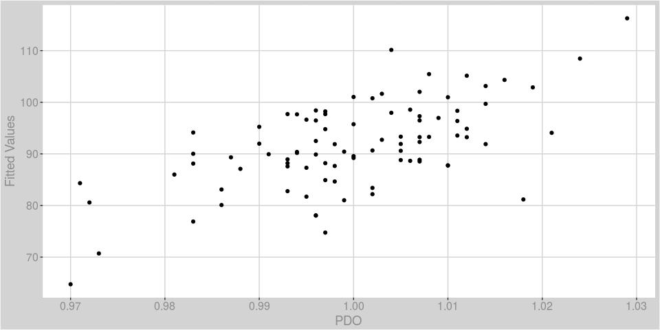

```r
ggplot(data.frame(x = team_past_summary_df$PDO, y = team_lm$fitted.values), aes(x=x, y=y)) + geom_point() + labs(x="PDO", y="Fitted Values") + theme(plot.title = element_text(hjust = 0.5)) + theme(plot.background = element_rect(fill = "lightgrey"), panel.background = element_rect(fill = "white"), panel.grid.major.x = element_line(color = "lightgrey"), panel.grid.major.y = element_line(color = "lightgrey")) + theme(axis.text = element_text(size=12, color = "grey55"), axis.title = element_text(size=14, color = "grey55"), title = element_text(size=14, color = "grey55"))
```

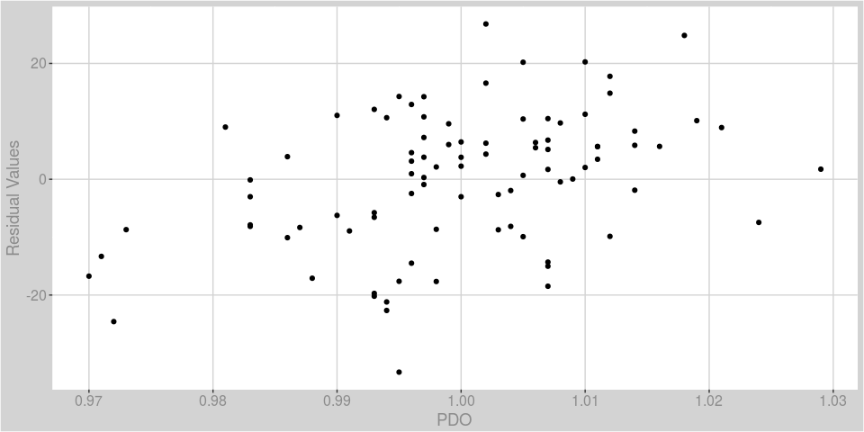

```r
ggplot(data.frame(x = team_past_summary_df$PDO, y = team_lm$residuals), aes(x=x, y=y)) + geom_point() + labs(x="PDO", y="Residual Values") + theme(plot.title = element_text(hjust = 0.5)) + theme(plot.background = element_rect(fill = "lightgrey"), panel.background = element_rect(fill = "white"), panel.grid.major.x = element_line(color = "lightgrey"), panel.grid.major.y = element_line(color = "lightgrey")) + theme(axis.text = element_text(size=12, color = "grey55"), axis.title = element_text(size=14, color = "grey55"), title = element_text(size=14, color = "grey55"))
```

# Work from here

## Prediction

```r
season_home_adv_df <- season_schedule_df %>% filter(Date<Sys.Date()) %>% mutate(winner = ifelse(G.1 - G > 0, "H", "V"), count = 1) %>% group_by(winner) %>% summarize(count = sum(count))
home_adv = season_home_adv_df[season_home_adv_df$winner=="H",c("count")][[1]] / (season_home_adv_df[season_home_adv_df$winner=="V",c("count")][[1]])

season_ot_chance_df <- season_schedule_df %>% filter(Date<Sys.Date()) %>% mutate(ot = ifelse(Var.6=="OT" | Var.6=="SO","Y","N"), count = 1) %>% group_by(ot) %>% summarize(count = sum(count))
ot_chance <- season_ot_chance_df[season_ot_chance_df$ot=="Y",c("count")][[1]] / (season_ot_chance_df[season_ot_chance_df$ot=="Y",c("count")][[1]] + season_ot_chance_df[season_ot_chance_df$ot=="N",c("count")][[1]])

season_remaining_schedule_df <- season_schedule_df[,c("Date", "Visitor", "Home")] %>% filter(Date>Sys.Date())
season_remaining_schedule_df$Visitor_Abbr <- team_abbr_fun(season_remaining_schedule_df$Visitor)
season_remaining_schedule_df$Home_Abbr <- team_abbr_fun(season_remaining_schedule_df$Home)
season_remaining_schedule_df$Visitor_Weighted_Cap <- unname(unlist(sapply(season_remaining_schedule_df$Visitor_Abbr, function(x) {team_summary_df[team_summary_df$Team==x & team_summary_df$year==2018,c("est_weighted_cap")]})))
season_remaining_schedule_df$Home_Weighted_Cap <- unname(unlist(sapply(season_remaining_schedule_df$Home_Abbr, function(x) {team_summary_df[team_summary_df$Team==x & team_summary_df$year==2018,c("est_weighted_cap")]})))
season_remaining_schedule_df$Home_Weighted_Cap_Adj <- season_remaining_schedule_df$Home_Weighted_Cap * home_adv
season_remaining_schedule_df$Combined_Cap = season_remaining_schedule_df$Home_Weighted_Cap + season_remaining_schedule_df$Visitor_Weighted_Cap
#set.seed(2343)
season_remaining_schedule_df$ValuePicked <- sapply(season_remaining_schedule_df$Combined_Cap, function(x) {runif(1, 1, x)})
season_remaining_schedule_df$Winner <- ifelse(season_remaining_schedule_df$ValuePicked < season_remaining_schedule_df$Home_Weighted_Cap_Adj, season_remaining_schedule_df$Home_Abbr, season_remaining_schedule_df$Visitor_Abbr)
season_remaining_schedule_df$OT <- ifelse(season_remaining_schedule_df$Winner==season_remaining_schedule_df$Home_Abbr & season_remaining_schedule_df$ValuePicked > season_remaining_schedule_df$Home_Weighted_Cap_Adj - season_remaining_schedule_df$Combined_Cap * ot_chance/2, season_remaining_schedule_df$Visitor_Abbr,
                                          ifelse(season_remaining_schedule_df$Winner==season_remaining_schedule_df$Visitor_Abbr & season_remaining_schedule_df$ValuePicked < season_remaining_schedule_df$Home_Weighted_Cap_Adj + season_remaining_schedule_df$Combined_Cap * ot_chance/2, season_remaining_schedule_df$Home_Abbr, NA))

season_remaining_summary_df <- season_remaining_schedule_df %>% group_by(Winner, OT) %>% mutate(count = 1) %>% summarize(results = sum(count)) %>% gather(type, team, 1:2, na.rm = TRUE) %>% mutate(points = ifelse(type=="Winner",2*results,1*results)) %>% group_by(team) %>% summarize(points = sum(points))
```

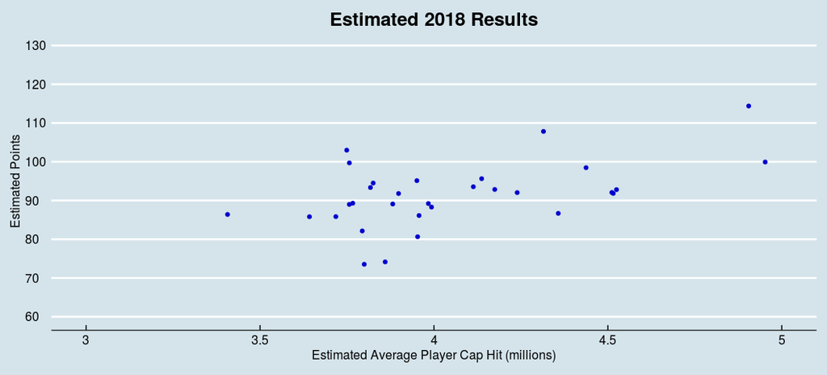

```r
team_prediction_df <- team_summary_df %>% filter(year==2018)
#team_prediction_df$RemainingPoints <- unname(unlist(sapply(team_prediction_df$Team, function(x) {season_remaining_summary_df[season_remaining_summary_df$team==x,c("points")]})))
#team_prediction_df$PredictedPointsSkaters <- team_prediction_df$points + team_prediction_df$RemainingPoints
#team_prediction_df$division <- factor(team_div_fun(team_prediction_df$Team))
#team_prediction_df <- team_prediction_df %>% group_by(division) %>% mutate(division_ranks = order(order(PredictedPointsSkaters, decreasing = TRUE)))

####Work on from here

team_prediction_df$PredictedPoints <- predict(team_step_lm, team_prediction_df)
team_prediction_df <- team_prediction_df %>% mutate(positionrank = rank(-points, ties.method = "average"), estpositionrank = rank(-PredictedPoints, ties.method = "average")) %>% mutate(year = factor(year))
ggplot(team_prediction_df, aes(x=est_weighted_cap, y=PredictedPoints, color=year)) + geom_point() + theme_economist() + labs(x = "Estimated Average Player Cap Hit (millions)", y = "Estimated Points", title = "Estimated 2018 Results") + theme(plot.title = element_text(hjust = 0.5), text = element_text(size=12), legend.position = "none") + scale_x_continuous(limits = c(3000000, 5000000), breaks = (seq(3000000, 5000000, 500000)), labels = formattermillion) + scale_y_continuous(limits = c(60, 130), breaks = (seq(60, 130, 10))) + scale_color_manual(values = c("mediumblue"))
```

```r
colnames(team_prediction_df) <- c("Team", "year", "weighted", "estweighted", "captotal", "time", "players", "weighted_cap",  "Estimated_Cap", "cap", "GP","Wins", "CF_Perc", "FF_Perc", "SF_Perc", "GF", "HDCF","HDSV_Perc", "MDSV_Perc", "LDSV_Perc", "SV_Perc", "PDO", "Points", "Predicted_Points", "Rank", "Est_Rank")
```

### Predicted finishing points for each team based on glm

```r
head(team_prediction_df %>% arrange(-Predicted_Points), n = 32) %>% select(Team, Estimated_Cap, LDSV_Perc, MDSV_Perc, HDSV_Perc, PDO, Points, Rank, Est_Rank, Predicted_Points) %>% kable("html") %>% kable_styling()
```

| Team | Estimated_Cap | LDSV_Perc | MDSV_Perc | HDSV_Perc | PDO | Points | Rank | Est_Rank | Predicted_Points |
| --- | --- | --- | --- | --- | --- | --- | --- | --- | --- |
| NSH | 4904822 | 98.63 | 96.71 | 89.87 | 1.017 | 113 | 1.0 | 1 | 114.38986 |
| WSH | 4314813 | 99.34 | 96.46 | 88.00 | 1.017 | 103 | 6.5 | 2 | 107.82974 |
| ANA | 3749154 | 99.22 | 96.78 | 88.69 | 1.013 | 95 | 13.5 | 3 | 102.98718 |
| WPG | 4952280 | 98.51 | 95.59 | 87.46 | 1.010 | 110 | 3.0 | 4 | 99.93096 |
| L.A | 3756828 | 98.67 | 96.99 | 89.20 | 1.011 | 96 | 11.0 | 5 | 99.70307 |
| T.B | 4437275 | 98.87 | 95.38 | 88.43 | 1.022 | 110 | 3.0 | 6 | 98.46693 |
| PHI | 4137091 | 98.75 | 96.38 | 86.98 | 1.001 | 94 | 15.0 | 7 | 95.63079 |
| COL | 3950868 | 98.50 | 96.56 | 88.29 | 1.015 | 93 | 16.0 | 8 | 95.12640 |
| CBJ | 3825226 | 98.52 | 96.43 | 88.89 | 1.002 | 96 | 11.0 | 9 | 94.50140 |
| S.J | 4113161 | 98.79 | 96.32 | 86.31 | 0.993 | 98 | 8.5 | 10 | 93.54898 |
| STL | 3817369 | 98.71 | 96.92 | 86.58 | 1.000 | 92 | 17.0 | 11 | 93.34748 |
| MTL | 4174710 | 98.63 | 96.55 | 85.87 | 0.985 | 69 | 28.5 | 12 | 92.84988 |
| FLA | 4524811 | 98.51 | 96.02 | 85.90 | 0.997 | 90 | 18.5 | 13 | 92.80645 |
| CHI | 4511438 | 98.29 | 95.59 | 87.60 | 0.990 | 74 | 24.5 | 14 | 92.06710 |
| NYR | 4239264 | 98.86 | 94.54 | 89.04 | 0.999 | 77 | 22.0 | 15 | 92.03724 |
| CGY | 4515509 | 97.88 | 96.62 | 86.75 | 0.986 | 82 | 20.0 | 16 | 91.83373 |
| BOS | 3898193 | 98.52 | 96.08 | 88.37 | 1.005 | 110 | 3.0 | 17 | 91.80096 |
| TOR | 3766606 | 98.21 | 96.49 | 88.39 | 1.019 | 103 | 6.5 | 18 | 89.30028 |
| NYI | 3983881 | 98.43 | 96.76 | 85.78 | 1.005 | 76 | 23.0 | 19 | 89.21358 |
| VGK | 3881412 | 98.57 | 96.24 | 86.88 | 1.007 | 109 | 5.0 | 20 | 89.09581 |
| DAL | 3756601 | 98.41 | 94.96 | 91.10 | 1.002 | 90 | 18.5 | 21 | 88.99175 |
| VAN | 3992976 | 98.02 | 96.68 | 87.26 | 0.993 | 70 | 27.0 | 22 | 88.29598 |
| BUF | 4357301 | 98.84 | 95.37 | 84.64 | 0.979 | 62 | 31.0 | 23 | 86.67624 |
| ARI | 3406620 | 98.49 | 96.57 | 87.73 | 0.995 | 69 | 28.5 | 24 | 86.39398 |
| DET | 3957081 | 98.58 | 95.91 | 86.16 | 0.995 | 72 | 26.0 | 25 | 86.12457 |
| MIN | 3717878 | 98.15 | 96.09 | 88.54 | 1.010 | 98 | 8.5 | 26 | 85.83963 |
| EDM | 3641982 | 98.72 | 95.60 | 87.72 | 0.993 | 74 | 24.5 | 27 | 85.81040 |
| N.J | 3793821 | 98.47 | 96.13 | 85.42 | 0.997 | 95 | 13.5 | 28 | 82.14298 |
| PIT | 3952996 | 98.78 | 94.23 | 87.30 | 0.981 | 96 | 11.0 | 29 | 80.64963 |
| CAR | 3859672 | 98.53 | 93.85 | 87.28 | 0.979 | 81 | 21.0 | 30 | 74.15212 |
| OTT | 3799476 | 98.26 | 95.10 | 85.51 | 0.986 | 65 | 30.0 | 31 | 73.53025 |

### Predicted finishing points for each team based on weighted player values only

```r
head(team_prediction_df %>% arrange(-Estimated_Cap), n = 32) %>% select(Team, Estimated_Cap, LDSV_Perc, MDSV_Perc, HDSV_Perc, PDO, Points, Rank, Est_Rank, Predicted_Points) %>% kable("html") %>% kable_styling()
```

| Team | Estimated_Cap | LDSV_Perc | MDSV_Perc | HDSV_Perc | PDO | Points | Rank | Est_Rank | Predicted_Points |
| --- | --- | --- | --- | --- | --- | --- | --- | --- | --- |
| WPG | 4952280 | 98.51 | 95.59 | 87.46 | 1.010 | 110 | 3.0 | 4 | 99.93096 |
| NSH | 4904822 | 98.63 | 96.71 | 89.87 | 1.017 | 113 | 1.0 | 1 | 114.38986 |
| FLA | 4524811 | 98.51 | 96.02 | 85.90 | 0.997 | 90 | 18.5 | 13 | 92.80645 |
| CGY | 4515509 | 97.88 | 96.62 | 86.75 | 0.986 | 82 | 20.0 | 16 | 91.83373 |
| CHI | 4511438 | 98.29 | 95.59 | 87.60 | 0.990 | 74 | 24.5 | 14 | 92.06710 |
| T.B | 4437275 | 98.87 | 95.38 | 88.43 | 1.022 | 110 | 3.0 | 6 | 98.46693 |
| BUF | 4357301 | 98.84 | 95.37 | 84.64 | 0.979 | 62 | 31.0 | 23 | 86.67624 |
| WSH | 4314813 | 99.34 | 96.46 | 88.00 | 1.017 | 103 | 6.5 | 2 | 107.82974 |
| NYR | 4239264 | 98.86 | 94.54 | 89.04 | 0.999 | 77 | 22.0 | 15 | 92.03724 |
| MTL | 4174710 | 98.63 | 96.55 | 85.87 | 0.985 | 69 | 28.5 | 12 | 92.84988 |
| PHI | 4137091 | 98.75 | 96.38 | 86.98 | 1.001 | 94 | 15.0 | 7 | 95.63079 |
| S.J | 4113161 | 98.79 | 96.32 | 86.31 | 0.993 | 98 | 8.5 | 10 | 93.54898 |
| VAN | 3992976 | 98.02 | 96.68 | 87.26 | 0.993 | 70 | 27.0 | 22 | 88.29598 |
| NYI | 3983881 | 98.43 | 96.76 | 85.78 | 1.005 | 76 | 23.0 | 19 | 89.21358 |
| DET | 3957081 | 98.58 | 95.91 | 86.16 | 0.995 | 72 | 26.0 | 25 | 86.12457 |
| PIT | 3952996 | 98.78 | 94.23 | 87.30 | 0.981 | 96 | 11.0 | 29 | 80.64963 |
| COL | 3950868 | 98.50 | 96.56 | 88.29 | 1.015 | 93 | 16.0 | 8 | 95.12640 |
| BOS | 3898193 | 98.52 | 96.08 | 88.37 | 1.005 | 110 | 3.0 | 17 | 91.80096 |
| VGK | 3881412 | 98.57 | 96.24 | 86.88 | 1.007 | 109 | 5.0 | 20 | 89.09581 |
| CAR | 3859672 | 98.53 | 93.85 | 87.28 | 0.979 | 81 | 21.0 | 30 | 74.15212 |
| CBJ | 3825226 | 98.52 | 96.43 | 88.89 | 1.002 | 96 | 11.0 | 9 | 94.50140 |
| STL | 3817369 | 98.71 | 96.92 | 86.58 | 1.000 | 92 | 17.0 | 11 | 93.34748 |
| OTT | 3799476 | 98.26 | 95.10 | 85.51 | 0.986 | 65 | 30.0 | 31 | 73.53025 |
| N.J | 3793821 | 98.47 | 96.13 | 85.42 | 0.997 | 95 | 13.5 | 28 | 82.14298 |
| TOR | 3766606 | 98.21 | 96.49 | 88.39 | 1.019 | 103 | 6.5 | 18 | 89.30028 |
| L.A | 3756828 | 98.67 | 96.99 | 89.20 | 1.011 | 96 | 11.0 | 5 | 99.70307 |
| DAL | 3756601 | 98.41 | 94.96 | 91.10 | 1.002 | 90 | 18.5 | 21 | 88.99175 |
| ANA | 3749154 | 99.22 | 96.78 | 88.69 | 1.013 | 95 | 13.5 | 3 | 102.98718 |
| MIN | 3717878 | 98.15 | 96.09 | 88.54 | 1.010 | 98 | 8.5 | 26 | 85.83963 |
| EDM | 3641982 | 98.72 | 95.60 | 87.72 | 0.993 | 74 | 24.5 | 27 | 85.81040 |
| ARI | 3406620 | 98.49 | 96.57 | 87.73 | 0.995 | 69 | 28.5 | 24 | 86.39398 |

## Notes

1. Goaltending value was not calculated.
2. This analysis does not take into account scheduling, which can greatly impact the possible number of points for each team.
3. Relative values for advanced statistics (e.g. Corsi, Fenwick) should be pulled from other data sources and analyzed.
4. Given recent rule changes, it appears the average number of goals scored per game has now increased from previous years.

```r
scoring_df <- team_summary_df %>% group_by(year) %>% summarize(GPT = sum(GP), GFT = sum(GF)) %>% mutate(GPG = GFT / GPT)
scoring_df %>% arrange(year) %>% rename(games_played = GPT, goals_for = GFT, goals_per_game_per_team = GPG) %>% kable("html") %>% kable_styling()
```

| year | games_played | goals_for | goals_per_game_per_team |
| --- | --- | --- | --- |
| 2015 | 2460 | 4404 | 1.790244 |
| 2016 | 2460 | 4248 | 1.726829 |
| 2017 | 2460 | 4475 | 1.819106 |
| 2018 | 2472 | 4752 | 1.922330 |